# Environmental Data Preparation

Glenn Dunshea

2025-02-12

# 1 Southern Persian Gulf long term coral growth

## 1.1 Environmental Data Preparation

### 1.1.1 Install required packages

This code installs all the packages required to prepare, summarize and make some basic visualisations of the environmental data to merge with the coral growth dataset.

```r
# Install any missing packages (CRAN + one GitHub package)
cran_pkgs <- c(
  "zoo","TTR","lattice","tidyverse","ggplot2","lubridate",
  "data.table","broom","tibbletime"
)
to_install <- setdiff(cran_pkgs, rownames(installed.packages()))
if (length(to_install)) install.packages(to_install, repos = "https://cloud.r-project.org")

if (!requireNamespace("devtools", quietly = TRUE))
  install.packages("devtools", repos = "https://cloud.r-project.org")

if (!requireNamespace("dbcaDHW", quietly = TRUE)) {
  devtools::install_github("dbca-wa/dbcaDHW", upgrade = "never", quiet = TRUE)
}

knitr::opts_chunk$set(echo = TRUE)
```

### 1.1.2 Coral Growth Data

The coral growth data for this analysis are variables related to the growth of individual colonies collected from the densitometric analysis of x-rays of 1 inch wide slices, cut down the central growth plane, of individual coral colonies from three Persian Gulf sites and two sites off the coast of Oman. The growth variables are measured in yearly increments, so environmental data must also be summarized in yearly increments.

Lets look at the structure of the growth data first:

```r
onyr <- read.csv("rawdata/maxvalues-year2000onwards.csv")
head(onyr)
```

|  | year | site | colony | track | sample | calc | extension | density | hdbands | partmort | height | dia |
| --- | --- | --- | --- | --- | --- | --- | --- | --- | --- | --- | --- | --- |
| 1 | 2000 | AlAqah | ala12 | t1 | ala12_t1 | 0.797 | 0.6559 | 1.534612 | 0 | 0 | 13.5 | 23 |
| 2 | 2000 | AlAqah | ala12 | t2 | ala12_t2 | 1.007 | 0.5701 | 1.397308 | 0 | 0 | 13.5 | 23 |
| 3 | 2000 | Dibba | dib01 | t1 | dib01_t1 | 0.956 | 0.7467 | 1.280707 | 0 | 0 | NA | NA |
| 4 | 2000 | Dibba | dib01 | t2 | dib01_t2 | 0.526 | 0.3784 | 1.390043 | 0 | 0 | NA | NA |
| 5 | 2000 | Dibba | dib04 | t1 | dib04_t1 | 0.940 | 0.8173 | 1.150707 | 0 | 0 | 14.0 | 28 |
| 6 | 2000 | Dibba | dib04 | t2 | dib04_t2 | 1.335 | 1.0998 | 1.213488 | 0 | 0 | 14.0 | 28 |

```r
summary(onyr)
```

```
##       year          site              colony             track
##  Min.   :2000   Length:768         Length:768         Length:768
##  1st Qu.:2005   Class :character   Class :character   Class :character
##  Median :2008   Mode  :character   Mode  :character   Mode  :character
##  Mean   :2008
##  3rd Qu.:2011
##  Max.   :2013
##
##     sample               calc          extension         density
##  Length:768         Min.   :0.1650   Min.   :0.1665   Min.   :0.8693
##  Class :character   1st Qu.:0.5965   1st Qu.:0.4440   1st Qu.:1.1948
##  Mode  :character   Median :0.7695   Median :0.5750   Median :1.3423
##                     Mean   :0.8211   Mean   :0.6044   Mean   :1.3722
##                     3rd Qu.:1.0170   3rd Qu.:0.7232   3rd Qu.:1.5187
##                     Max.   :1.9930   Max.   :2.9767   Max.   :2.3394
##                     NA's   :4        NA's   :9        NA's   :7
##     hdbands           partmort            height            dia
##  Min.   :0.00000   Min.   :0.000000   Min.   : 4.000   Min.   :11.00
##  1st Qu.:0.00000   1st Qu.:0.000000   1st Qu.: 7.000   1st Qu.:15.00
##  Median :0.00000   Median :0.000000   Median : 8.500   Median :16.00
##  Mean   :0.08333   Mean   :0.003906   Mean   : 8.814   Mean   :17.94
##  3rd Qu.:0.00000   3rd Qu.:0.000000   3rd Qu.:11.000   3rd Qu.:22.00
##  Max.   :1.00000   Max.   :1.000000   Max.   :14.000   Max.   :28.00
##                                       NA's   :50       NA's   :50
```

```r
# number of unique colonies
length(unique(onyr$colony))
```

```
## [1] 38
```

```r
# number of unique sites = 5
unique(onyr$site)
```

```
## [1] "AlAqah"     "Dibba"      "RasGhanada" "Saadiyat"   "Delma"
```

Here is a simply plot showing individual colony relationships between diameter and height

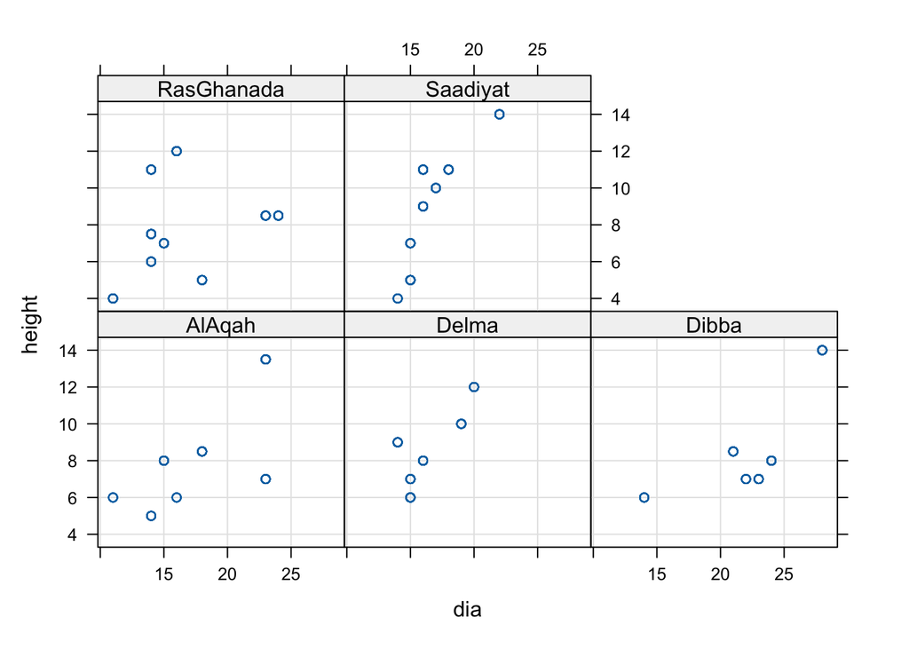

So we have 768 measurements from 38 colonies from five sites. The coral growth data record growth from 2000-2013.

### 1.1.3 Environmental summaries

Lets look at the structure of the environmental variables, which are data products derived from satellite observations. They consist of sea surface temperature metrics and current speed and direction metrics from each of the sites.Since we are aiming to examine environmental effects (SST & current speed) on coral growth, we need to be able to summarize the environmenal data we have into a form amenable for analysis of the coral growth data, which is metrics of growth per year.

Here is the Sea Surface Temperature (SST) data for each site. We can see that the satelite data products summarizes the SST daily and the dataset starts in 1985. It is the same for all data from all sites and current speed as well:

```r
temp <- read.csv("rawdata/ctemp_sst_mod.csv")
str(temp)
```

```
## 'data.frame':    12370 obs. of  11 variables:
##  $ date      : chr  "1985JAN01" "1985JAN02" "1985JAN03" "1985JAN04" ...
##  $ date1     : chr  "1/1/85" "2/1/85" "3/1/85" "4/1/85" ...
##  $ yearday   : int  1 2 3 4 5 6 7 8 9 10 ...
##  $ Year      : int  1985 1985 1985 1985 1985 1985 1985 1985 1985 1985 ...
##  $ Delma     : num  22.7 22.6 22.5 22.2 22.1 ...
##  $ RasGhanada: num  23.3 23.1 23 22.8 22.8 ...
##  $ Saadiyat  : num  23.3 23.1 23 22.7 22.7 ...
##  $ AlAqah    : num  24 23.9 23.9 23.9 23.9 ...
##  $ Dibba     : num  24 23.9 23.9 23.8 23.8 ...
##  $ month     : chr  "JAN" "JAN" "JAN" "JAN" ...
##  $ season    : chr  "winter" "winter" "winter" "winter" ...
```

```r
### Resetting variable names to make it easier to reshape dataset after adding moving averages
temp1 <- temp[,5:9]
colnames(temp1) <- paste(colnames(temp1), "raw", sep = ".")
temp <- cbind(temp[,c(1,2,3,4,10,11)], temp1)
```

Now lets smooth out some the the effect of daily variation and get some moving averages of temporal trends. We will use a centered moving average to capture coldest and hottest periods in each year:

```r
library(tidyverse)
temp11 <- temp %>%
  select(date, date1, yearday, Year, month, season, Delma.raw, RasGhanada.raw, Saadiyat.raw, AlAqah.raw, Dibba.raw) %>%
  mutate(Delma.CMA = rollmean(Delma.raw, k = 61, fill = NA),
         RasGhanada.CMA = rollmean(RasGhanada.raw, k = 61, fill = NA),
         Saadiyat.CMA = rollmean(Saadiyat.raw, k = 61, fill = NA),
         AlAqah.CMA = rollmean(AlAqah.raw, k = 61, fill = NA),
         Dibba.CMA = rollmean(Dibba.raw, k = 61, fill = NA))

### Reformatting and making some plots to visualize SST. Only looking at SST from one site and two different years:
###
temp11$date1 <- as.Date(temp11$date1, '%d/%m/%y')
str(temp)
```

```
## 'data.frame':    12370 obs. of  11 variables:
##  $ date          : chr  "1985JAN01" "1985JAN02" "1985JAN03" "1985JAN04" ...
##  $ date1         : chr  "1/1/85" "2/1/85" "3/1/85" "4/1/85" ...
##  $ yearday       : int  1 2 3 4 5 6 7 8 9 10 ...
##  $ Year          : int  1985 1985 1985 1985 1985 1985 1985 1985 1985 1985 ...
##  $ month         : chr  "JAN" "JAN" "JAN" "JAN" ...
##  $ season        : chr  "winter" "winter" "winter" "winter" ...
##  $ Delma.raw     : num  22.7 22.6 22.5 22.2 22.1 ...
##  $ RasGhanada.raw: num  23.3 23.1 23 22.8 22.8 ...
##  $ Saadiyat.raw  : num  23.3 23.1 23 22.7 22.7 ...
##  $ AlAqah.raw    : num  24 23.9 23.9 23.9 23.9 ...
##  $ Dibba.raw     : num  24 23.9 23.9 23.8 23.8 ...
```

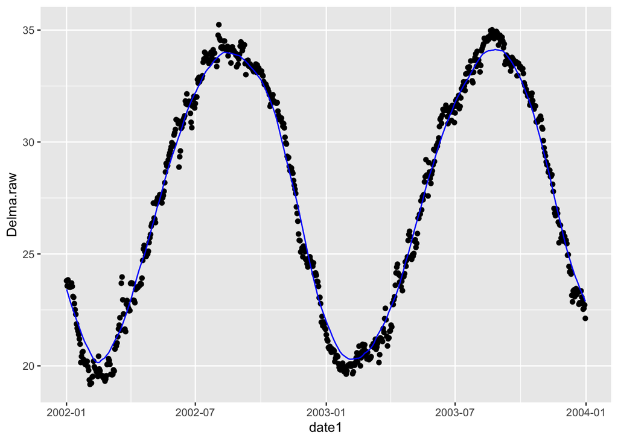

```r
require(ggplot2)
temp98 <- subset(temp11, Year ==2002 | Year ==2003)
ggplot( data = temp98, aes(date1, Delma.raw )) + geom_point() +
  #geom_line(data = temp98, aes(date1, Delma.raw ), color = "red")+
  geom_line(data = temp98, aes(date1, Delma.CMA ), color = "blue")
```

The data needs reshaping so raw SST (Delma, RasGhanada, Saadiyat, AlAqah, Dibba) and 61 day centered averaged temps are in single columns with a site factor level instead (removing first 30 & last 30 days of data first to remove all NAs produced from the centred moving average)

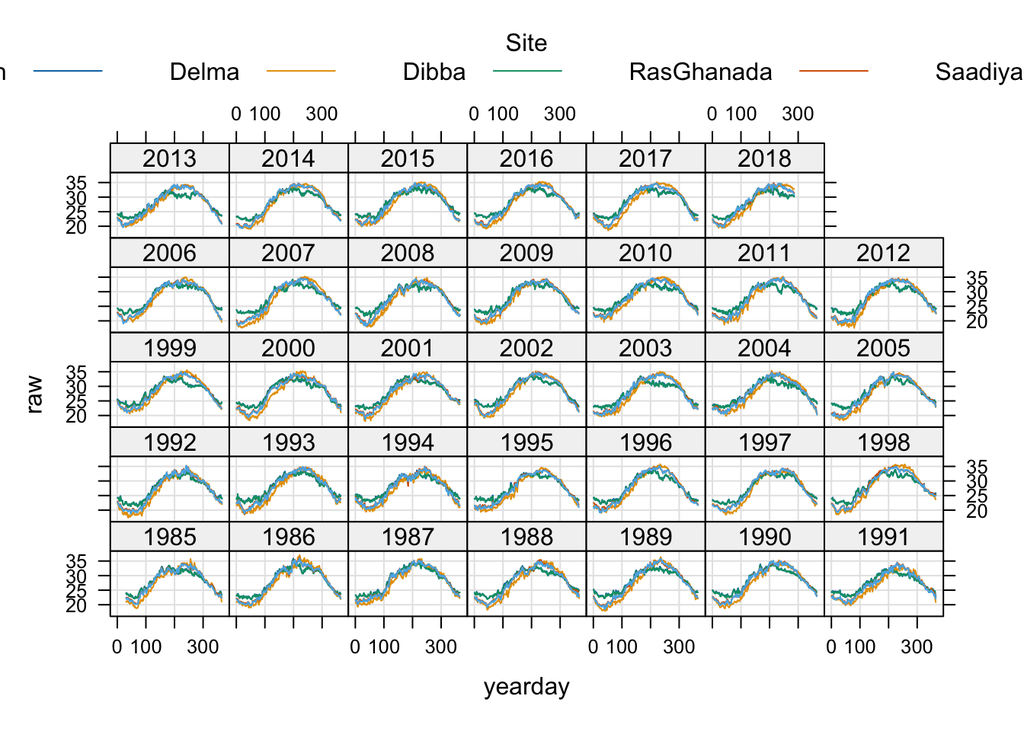

```r
temp11 <- temp11[31:(nrow(temp11)-31),]
templong <- temp11 %>%
  gather("key", "value", -date, -date1, -yearday, -Year, -month, -season) %>%
  separate(key, c("Site", "raw_CMA"), sep = "\\.") %>%
  spread(raw_CMA, value)

xyplot(raw ~ yearday | as.factor(Year) , data = templong,
       group = Site, t="l",
       grid = TRUE, auto.key=list(space="top", columns=5,
                                  title="Site", cex.title=1,
                                  lines=TRUE, points=FALSE))
```

So we can see the expected annually cyclical nature of SST here.

Because we are interested in summarizing variables for each calendar year, we need a way to discriminate the different seasons from the temperature data itself in order to summarize, say seasonal(summer / winter) average temperatures or to use the rates of change between summer highs to winter and winter lows to summer each year. We need to do this because using static calendar dates to define these may not capture the appropriate data range for particular summary, because of temporal variation in seasons (e,g, a “late summer” or “early winter”. To begine with, lets detect and plot the90 days after coldest (blue) and hottest day of each year are detected (red) - checking a few different sites & only looking for a few different years 2003-2008

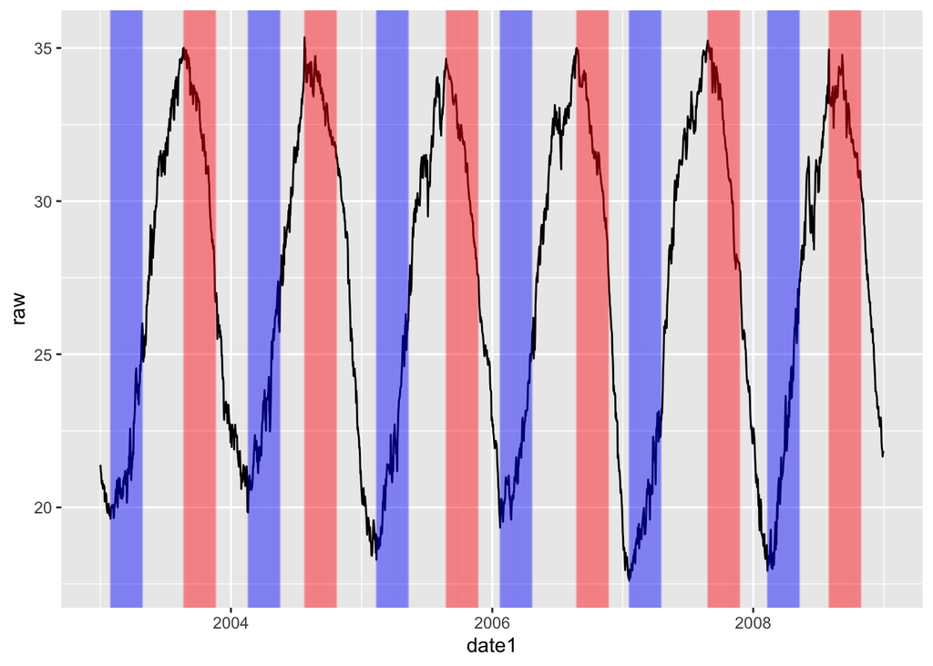

```r
plot_df <- templong %>%
  mutate(year = lubridate::year(date1)) %>%
  group_by(year, Site) %>%
  mutate(raw_min = +(raw == min(raw)),
         raw_max = +(raw == max(raw))) %>%
  ungroup() %>%
  mutate(raw_min = cumsum(raw_min - lag(raw_min, 90, default = 0)),
         raw_max = cumsum(raw_max - lag(raw_max, 90, default = 0)))
ggplot(
  plot_df %>%
    filter(Site == "Delma", Year >= 2003, Year <= 2008),
  aes(date1, raw)
) +
  geom_line() +
  geom_vline(
    aes(xintercept = date1),
    data = plot_df %>% filter(Site == "Delma", Year >= 2003, Year <= 2008, raw_min > 0),
    alpha = 0.1,
    colour = "blue"
  ) +
  geom_vline(
    aes(xintercept = date1),
    data = plot_df %>% filter(Site == "Delma", Year >= 2003, Year <= 2008, raw_max > 0),
    alpha = 0.1,
    colour = "red"
  )
```

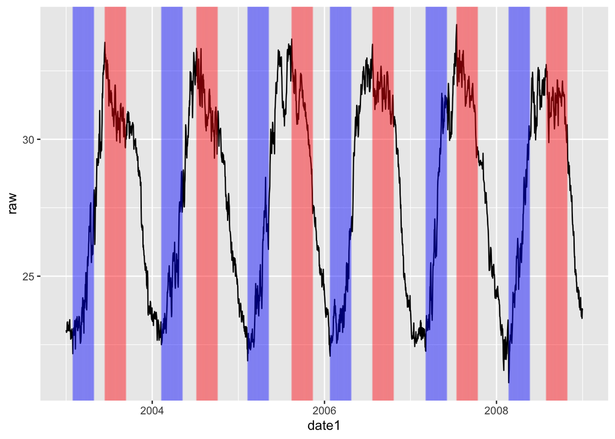

```r
ggplot(
  plot_df %>%
    filter(Site == "Dibba", Year >= 2003, Year <= 2008),
  aes(date1, raw)
) +
  geom_line() +
  geom_vline(
    aes(xintercept = date1),
    data = plot_df %>% filter(Site == "Dibba", Year >= 2003, Year <= 2008, raw_min > 0),
    alpha = 0.1,
    colour = "blue"
  ) +
  geom_vline(
    aes(xintercept = date1),
    data = plot_df %>% filter(Site == "Dibba", Year >= 2003, Year <= 2008, raw_max > 0),
    alpha = 0.1,
    colour = "red"
  )
```

We can now subset the raw data to be from the yearly minimum SST at each site for the 90 days after.

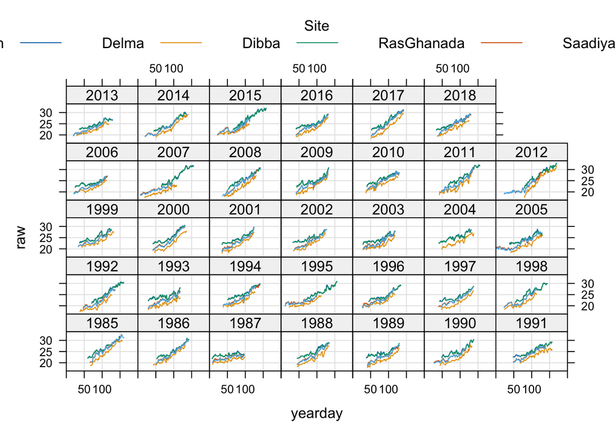

```r
raw_minroc <- subset(plot_df, raw_min > 0)
xyplot(raw ~ yearday | as.factor(Year) , data = raw_minroc,
       group = Site, type ="l", xlim = c(0,200),
       grid = TRUE, auto.key=list(space="top", columns=5,
                                  title="Site", cex.title=1,
                                  lines=TRUE, points=FALSE))
```

Ideally if we fit a simple linear regression to this line, it would give a measure of the rate of change toward summer from the coldest day of winter in that year. But it seems like a few problems to deal with first - For example, 2005 something weird has gone on at the site RasG. Other instances is where the coldestr day is on the 31st December, (RasG and Saadiyat) which bugs up the by year filtering, so we need to remove (RasG and Saadiyat, 31 dec 2004) running filtering again without those rows

```r
templong <- templong %>%
  filter(date1 != "2004-12-31" | Site != "RasGhanada" ) %>%
  filter(date1 != "2004-12-31" |  Site != "Saadiyat")
nrow(templong)
```

```
## [1] 61543
```

```r
plot_df <- templong %>%
  mutate(year = lubridate::year(date1)) %>%
  group_by(year, Site) %>%
  mutate(raw_min = +(raw == min(raw)),
         raw_max = +(raw == max(raw))) %>%
  ungroup() %>%
  mutate(raw_min = cumsum(raw_min - lag(raw_min, 90, default = 0)),
         raw_max = cumsum(raw_max - lag(raw_max, 90, default = 0)))
str(plot_df)
```

```
## tibble [61,543 × 12] (S3: tbl_df/tbl/data.frame)
##  $ date   : chr [1:61543] "1985JAN31" "1985FEB01" "1985FEB02" "1985FEB03" ...
##  $ date1  : Date[1:61543], format: "1985-01-31" "1985-02-01" ...
##  $ yearday: int [1:61543] 31 32 33 34 35 36 37 38 39 40 ...
##  $ Year   : int [1:61543] 1985 1985 1985 1985 1985 1985 1985 1985 1985 1985 ...
##  $ month  : chr [1:61543] "JAN" "FEB" "FEB" "FEB" ...
##  $ season : chr [1:61543] "winter" "winter" "winter" "winter" ...
##  $ Site   : chr [1:61543] "Delma" "Delma" "Delma" "Delma" ...
##  $ CMA    : num [1:61543] 20.9 20.9 20.8 20.8 20.7 ...
##  $ raw    : num [1:61543] 21.1 20.9 21 21 21.2 ...
##  $ year   : num [1:61543] 1985 1985 1985 1985 1985 ...
##  $ raw_min: int [1:61543] 0 0 0 0 0 0 0 0 0 0 ...
##  $ raw_max: int [1:61543] 0 0 0 0 0 0 0 0 0 0 ...
```

Now lets plotting again to make sure 90 days after coldest (blue) and hottest day of each year are detected (red) - checking a few different sites

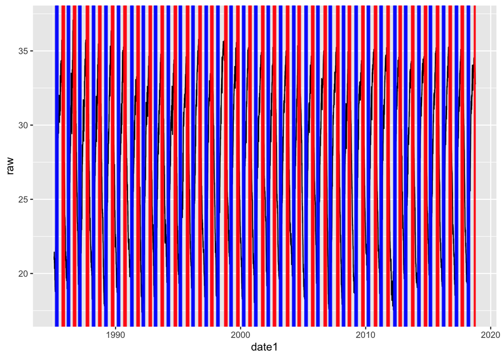

```r
ggplot(plot_df %>% filter(Site =="Delma"), aes(date1, raw)) +
  geom_line() +
  geom_vline(aes(xintercept = date1), plot_df %>% filter(Site =="Delma", raw_min > 0),
             alpha = 0.1, colour = "blue") +
  geom_vline(aes(xintercept = date1), plot_df %>% filter(Site =="Delma", raw_max > 0),
             alpha = 0.1, colour = "red")
```

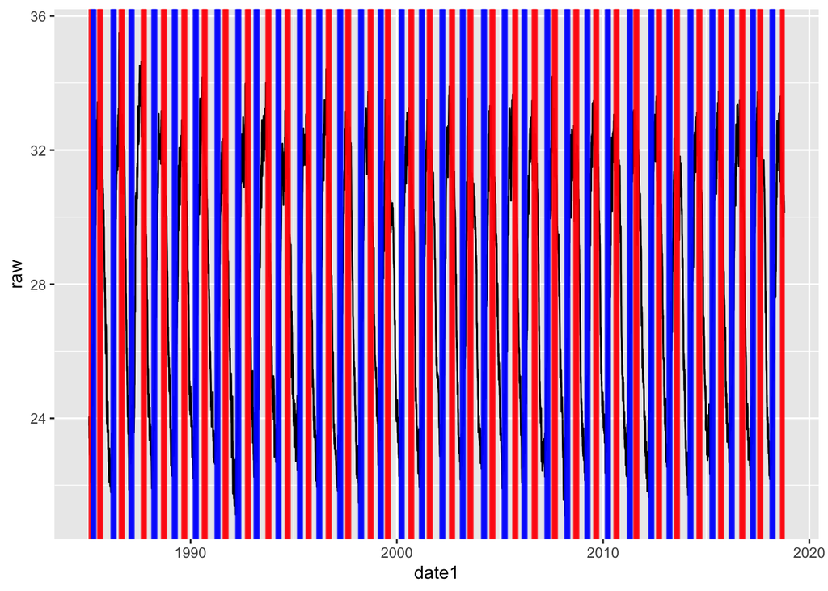

```r
ggplot(plot_df %>% filter(Site =="Dibba"), aes(date1, raw)) +
  geom_line() +
  geom_vline(aes(xintercept = date1), plot_df %>% filter(Site =="Dibba", raw_min > 0),
             alpha = 0.1, colour = "blue") +
  geom_vline(aes(xintercept = date1), plot_df %>% filter(Site =="Dibba", raw_max > 0),
             alpha = 0.1, colour = "red")
```

Now lets check to see if the data are now amenable to generating yearly rates of change between seasons for the 90 days after the coldest and hottest day of each year.

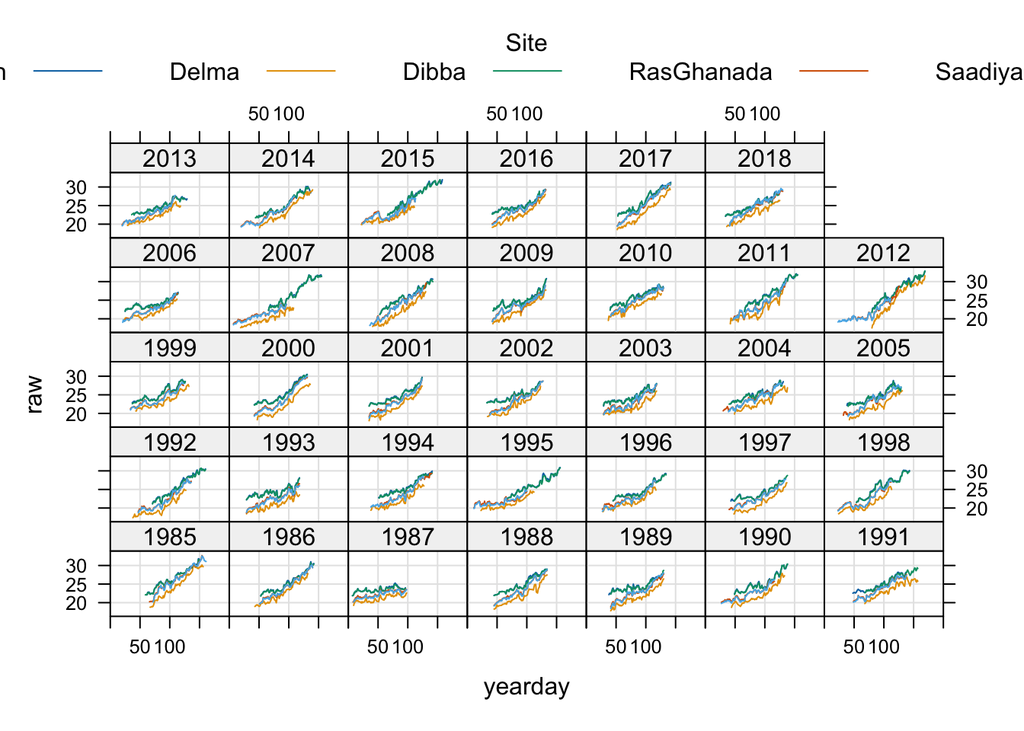

```r
###checking
raw_minroc <- subset(plot_df, raw_min > 0)
raw_maxroc <- subset(plot_df, raw_max > 0)
### winter to summer
xyplot(raw ~ yearday | as.factor(Year) , data = raw_minroc,
       group = Site, type ="l", xlim = c(0,200),
       grid = TRUE, auto.key=list(space="top", columns=5,
                                  title="Site", cex.title=1,
                                  lines=TRUE, points=FALSE))
```

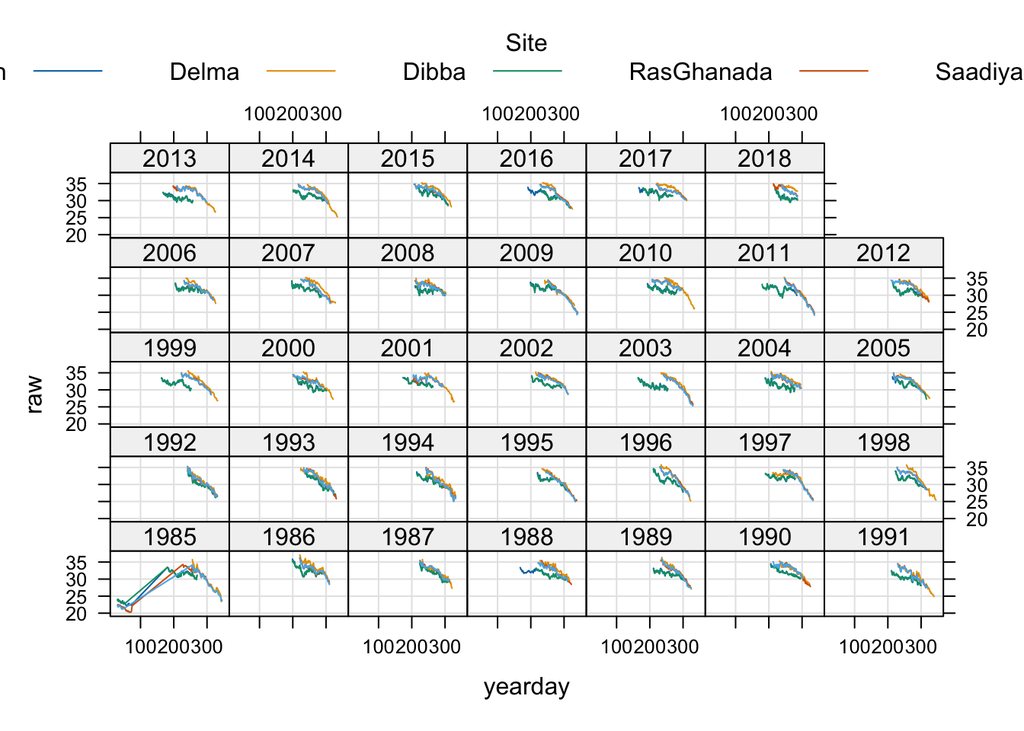

```r
###Summer to winter
xyplot(raw ~ yearday | as.factor(Year) , data = raw_maxroc,
       group = Site, type ="l", #xlim = c(0,200),
       grid = TRUE, auto.key=list(space="top", columns=5,
                                  title="Site", cex.title=1,
                                  lines=TRUE, points=FALSE))
```

In order to gather a measure of seasonal rates of change, we will fit a linear model within each year for SST~yearday where yearday will be normalized to the coldest (or hottest) day to day 1 before fitting regression so that intercepts are normalised to hottest/coldest day (as applicable)

```r
library(data.table)
str(raw_minroc)
```

```
## tibble [15,304 × 12] (S3: tbl_df/tbl/data.frame)
##  $ date   : chr [1:15304] "1985MAR08" "1985MAR09" "1985MAR10" "1985MAR11" ...
##  $ date1  : Date[1:15304], format: "1985-03-08" "1985-03-09" ...
##  $ yearday: int [1:15304] 67 68 69 70 71 72 73 74 75 76 ...
##  $ Year   : int [1:15304] 1985 1985 1985 1985 1985 1985 1985 1985 1985 1985 ...
##  $ month  : chr [1:15304] "MAR" "MAR" "MAR" "MAR" ...
##  $ season : chr [1:15304] "spring" "spring" "spring" "spring" ...
##  $ Site   : chr [1:15304] "Delma" "Delma" "Delma" "Delma" ...
##  $ CMA    : num [1:15304] 20.6 20.6 20.6 20.7 20.7 ...
##  $ raw    : num [1:15304] 18.8 18.8 18.9 19 18.9 ...
##  $ year   : num [1:15304] 1985 1985 1985 1985 1985 ...
##  $ raw_min: int [1:15304] 1 1 1 1 1 1 1 1 1 1 ...
##  $ raw_max: int [1:15304] 0 0 0 0 0 0 0 0 0 0 ...
```

```r
str(raw_maxroc)
```

```
## tibble [15,281 × 12] (S3: tbl_df/tbl/data.frame)
##  $ date   : chr [1:15281] "1985SEP13" "1985SEP14" "1985SEP15" "1985SEP16" ...
##  $ date1  : Date[1:15281], format: "1985-09-13" "1985-09-14" ...
##  $ yearday: int [1:15281] 256 257 258 259 260 261 262 263 264 265 ...
##  $ Year   : int [1:15281] 1985 1985 1985 1985 1985 1985 1985 1985 1985 1985 ...
##  $ month  : chr [1:15281] "SEP" "SEP" "SEP" "SEP" ...
##  $ season : chr [1:15281] "fall" "fall" "fall" "fall" ...
##  $ Site   : chr [1:15281] "Delma" "Delma" "Delma" "Delma" ...
##  $ CMA    : num [1:15281] 33.3 33.3 33.2 33.2 33.2 ...
##  $ raw    : num [1:15281] 35.7 35 34.4 34.6 34.4 ...
##  $ year   : num [1:15281] 1985 1985 1985 1985 1985 ...
##  $ raw_min: int [1:15281] 0 0 0 0 0 0 0 0 0 0 ...
##  $ raw_max: int [1:15281] 1 1 1 1 1 1 1 1 1 1 ...
```

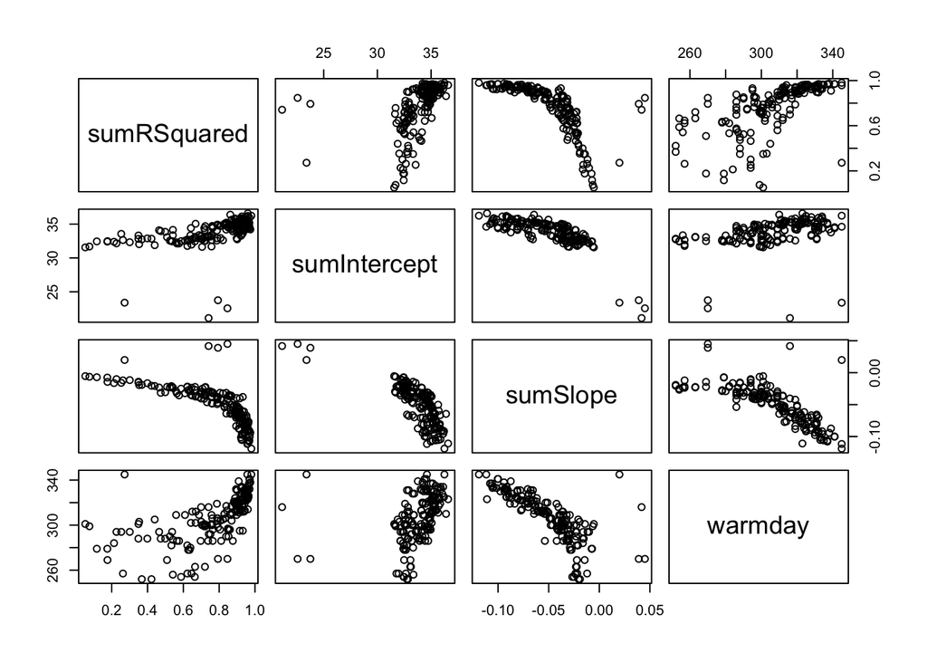

```r
raw_minroc$Site <- as.factor(raw_minroc$Site)
raw_maxroc$Site <- as.factor(raw_maxroc$Site)

raw_minroc <- raw_minroc %>%
  group_by(Site, year) %>%
  arrange(date1) %>%
  mutate(normday = yearday - min(yearday) + 1)

raw_maxroc <- raw_maxroc %>%
  group_by(Site, year) %>%
  arrange(date1) %>%
  mutate(normday = yearday - min(yearday) + 1)

###

library(dplyr)
library(tidyr)
library(purrr)
library(broom)

# Fit winter models by Site and year for SST rates of change:

wintrocfin <- raw_minroc %>%
  group_by(Site, year) %>%
  nest() %>%
  mutate(
    model = map(data, ~ lm(raw ~ normday, data = .x)),
    tidied = map(model, tidy),
    glanced = map(model, glance)
  ) %>%
  unnest(cols = c(tidied), names_sep = "_") %>%
  filter(tidied_term == "normday") %>%
  mutate(
    winSlope = tidied_estimate,
    winIntercept = map_dbl(model, ~ coef(.x)[1]),
    winRSquared = map_dbl(glanced, "r.squared")
  ) %>%
  select(Site, year, winRSquared, winIntercept, winSlope) %>%
  left_join(
    raw_minroc %>%
      group_by(Site, year) %>%
      summarise(ccoldday = min(yearday), .groups = "drop"),
    by = c("Site", "year")
  )

# Fit summer models by Site and year for SST rates of change:

summrocfin <- raw_maxroc %>%
  group_by(Site, year) %>%
  nest() %>%
  mutate(
    model = map(data, ~ lm(raw ~ normday, data = .x)),
    tidied = map(model, tidy),
    glanced = map(model, glance)
  ) %>%
  unnest(cols = c(tidied), names_sep = "_") %>%
  filter(tidied_term == "normday") %>%
  mutate(
    sumSlope = tidied_estimate,
    sumIntercept = map_dbl(model, ~ coef(.x)[1]),
    sumRSquared = map_dbl(glanced, "r.squared")
  ) %>%
  select(Site, year, sumRSquared, sumIntercept, sumSlope) %>%
  left_join(
    raw_maxroc %>%
      group_by(Site, year) %>%
      summarise(warmday = max(yearday), .groups = "drop"),
    by = c("Site", "year")
  )

pairs(summrocfin[,3:6])
```

Now that we have temperature rates of changed summarized, lets move onto to summarizing the hottest and coldest 61 days of each year to indicate the relative “hotness” of the annual summer and “coldness” of the annual winter at each site. For this we will use moving averages rather than daily temperatures, so as to remove daily noise from finding the hottest and coldest periods of each year.

```r
library(dplyr)
library(lubridate)
library(purrr)

# Adjust year so that DECEMBER is counted as part of the following winter - this is for years where the coldest period is close to the start of the year and therefore an attempt to extract the previous 30 days from the coldest moving average value in each yea is not possible.

templong <- templong %>%
  mutate(yearAD = ifelse(month == "DEC", Year + 1, Year))

# Identify coldest (min CMA) and hottest (max CMA) days per site-year
sumwin_df <- templong %>%
  group_by(yearAD, Site) %>%
  mutate(
    CMA_min = as.integer(CMA == min(CMA, na.rm = TRUE)),
    CMA_max = as.integer(CMA == max(CMA, na.rm = TRUE))
  ) %>%
  ungroup()

# Helper function to extract 61-day window around target indices
extract_window <- function(df, flag_col) {
  inds <- which(df[[flag_col]] == 1)
  rows <- unique(unlist(lapply(inds, function(i) (i - 30):(i + 30))))
  rows <- rows[rows > 0 & rows <= nrow(df)]  # Keep only valid indices
  result <- df[rows, ]
  result[[flag_col]] <- 1  # Mark entire window with flag
  return(result)
}

# Extract 61-day windows for coldest (winter) and hottest (summer) days
sumwin_win <- extract_window(sumwin_df, "CMA_min") %>%
  mutate(yearAD = ifelse(month == "DEC", Year + 1, Year))  # Ensure DEC counted in correct year

sumwin_sum <- extract_window(sumwin_df, "CMA_max")  # Summer doesn't need year fix

# Merge window flags back into full dataset
temp1 <- templong %>%
  left_join(sumwin_sum %>% select(date1, Site, CMA_max), by = c("date1", "Site")) %>%
  left_join(sumwin_win %>% select(date1, Site, CMA_min), by = c("date1", "Site"))

# Save a stable copy of the SST windows for later joins
sst_windows <- temp1 %>% dplyr::select(date1, Site, Year, month, CMA_min, CMA_max)
```

Lets now have a look at a few sites and time period to ensure we are indeed extracting the hottest and coldest periods of each season in each year at each site

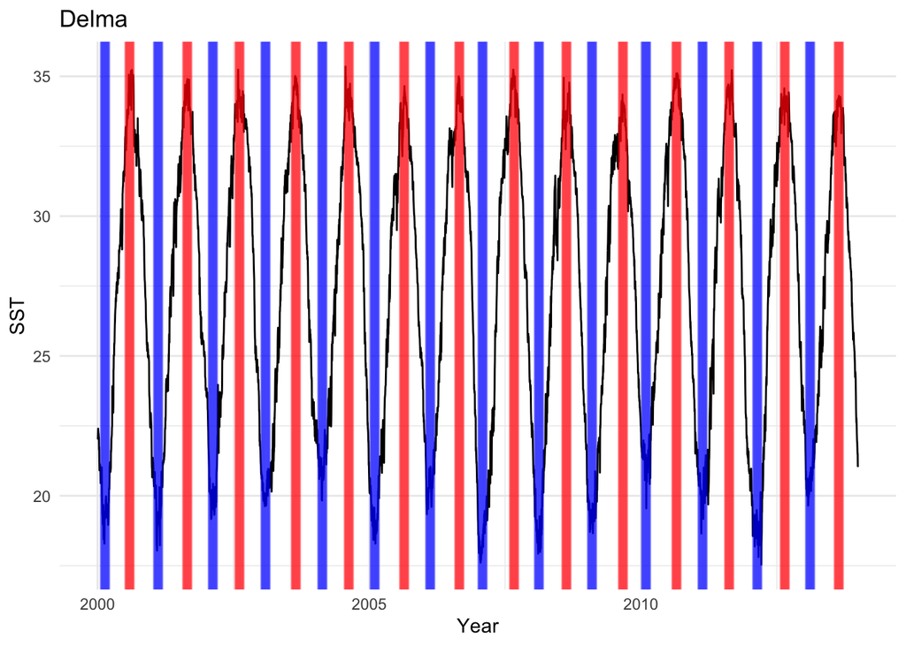

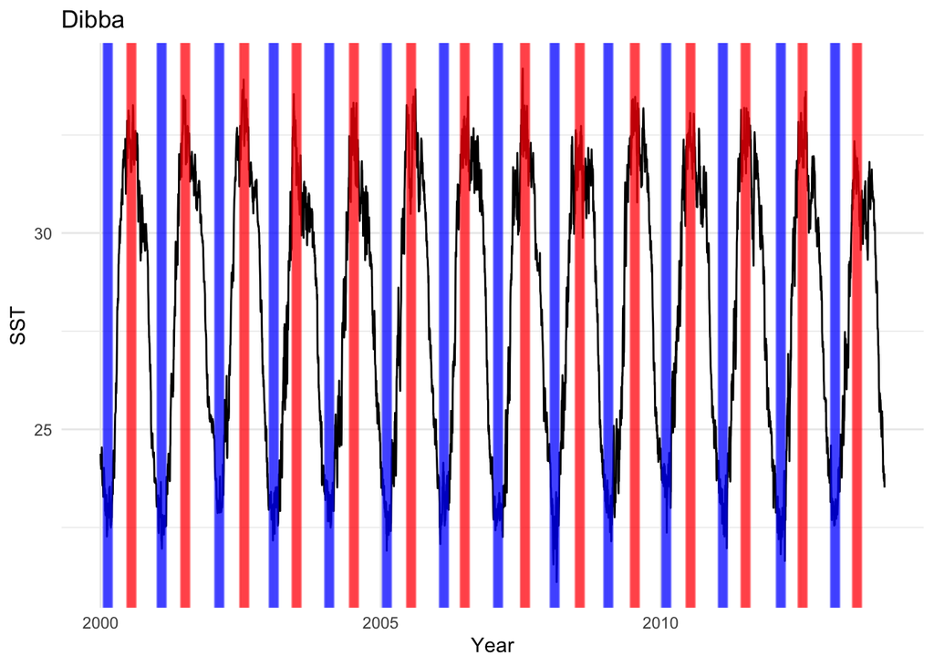

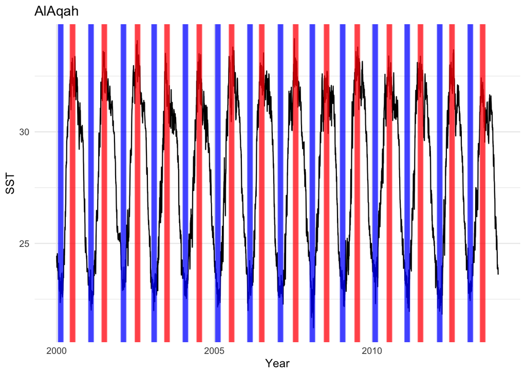

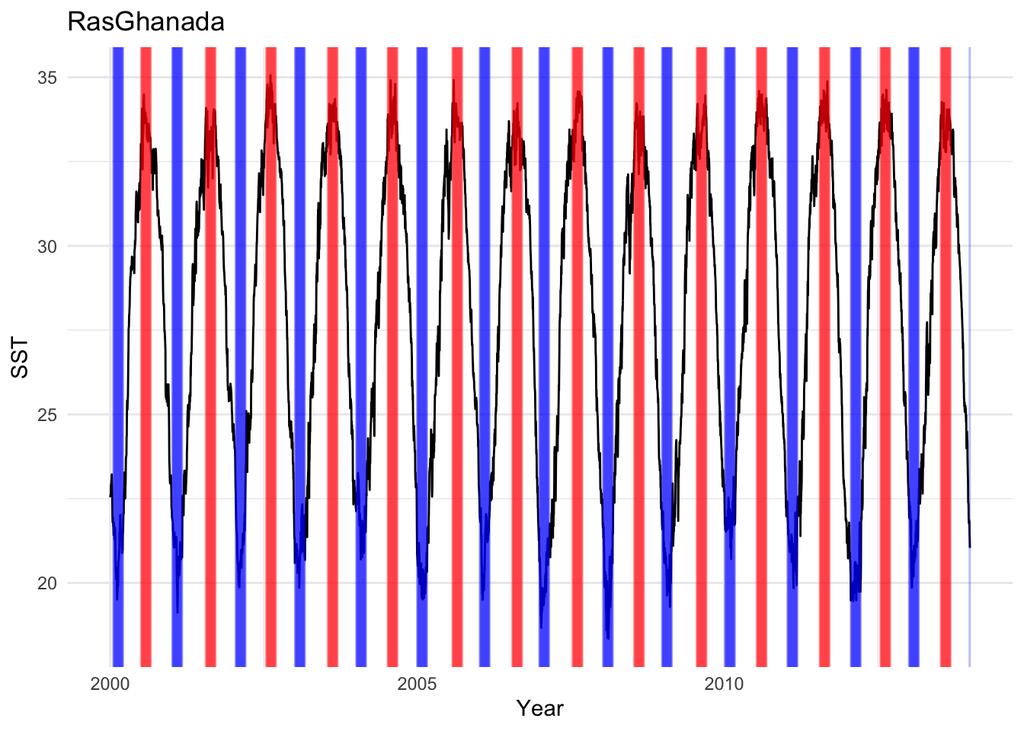

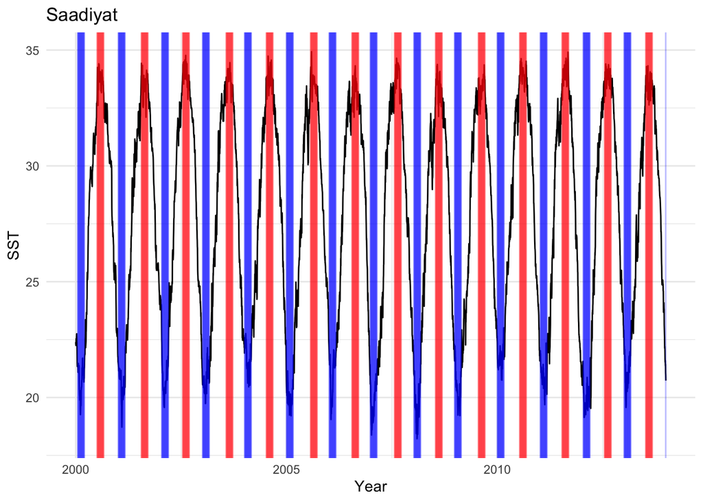

We can also visualise varition between sites

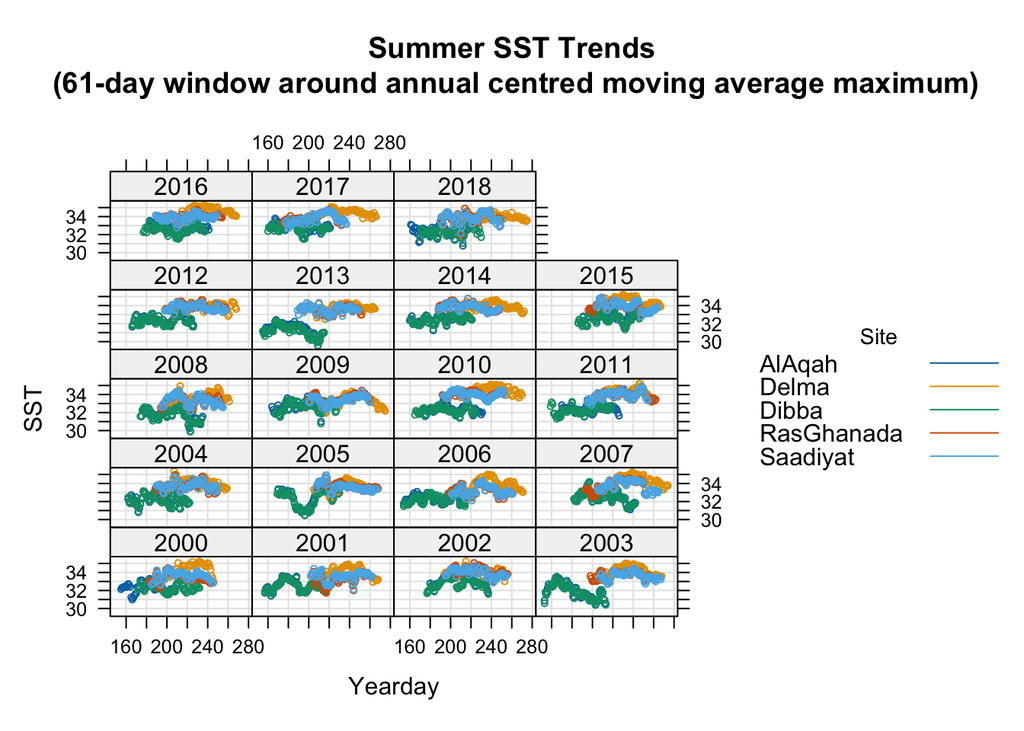

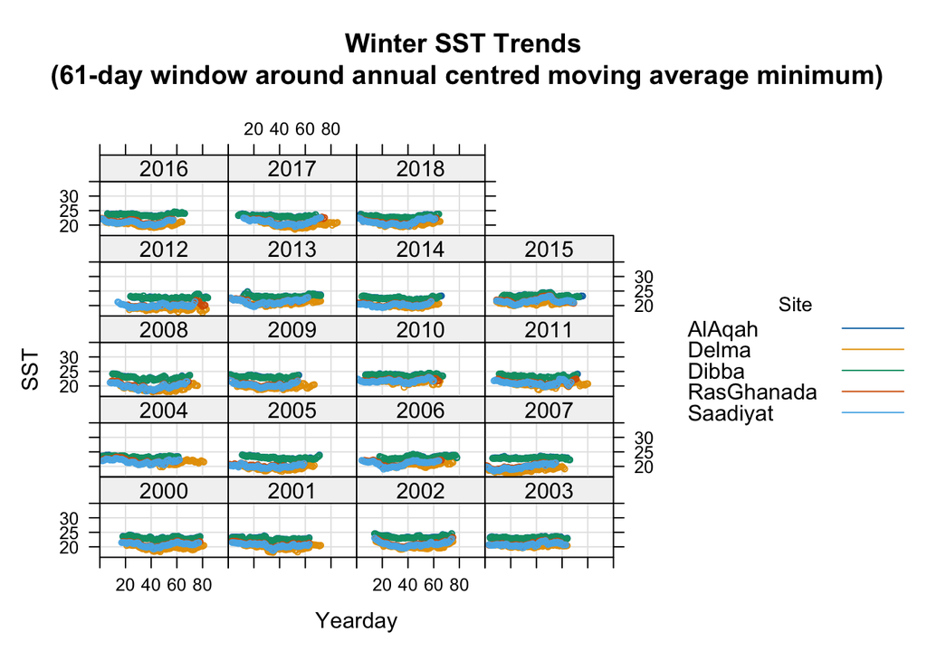

Looks good. Now we can easily summarize to extract minimum, maximum, range, mean and the SD (standard deviation) in temperature (representing temperature variability) for the hottest and coldest 61 days of each year at each site.

```r
library(dplyr)
library(purrr)

# Create winteryear column for situations where the coldest period overlaps with the start of the year
temp1 <- temp1 %>%
  mutate(
    Site = as.factor(Site),
    winteryear = ifelse(month == "DEC", Year + 1, Year)
  )

# Subset winter and summer temperature windows
wtemp <- temp1 %>% filter(CMA_min == 1)
stemp <- temp1 %>% filter(CMA_max == 1)

# Generic summarisation function for SST data
summarise_sst <- function(data, group_var, prefix) {
  data %>%
    group_by(across(all_of(group_var)), Site) %>%
    summarise(
      maxM = max(CMA, na.rm = TRUE),
      minM = min(CMA, na.rm = TRUE),
      avM  = mean(CMA, na.rm = TRUE),
      sdM  = sd(CMA, na.rm = TRUE),
      maxR = max(raw, na.rm = TRUE),
      minR = min(raw, na.rm = TRUE),
      avR  = mean(raw, na.rm = TRUE),
      sdR  = sd(raw, na.rm = TRUE),
      .groups = "drop"
    ) %>%
    mutate(site = Site) %>%
    select(-Site) %>%
    rename_with(~ paste0(prefix, .), -c(all_of(group_var), site))
}

# Get summaries
Wtsumall <- summarise_sst(wtemp, "winteryear", "Wt") %>%
  rename(year = winteryear) %>%
  mutate(
    WtrangeM = WtmaxM - WtminM,
    WtrangeR = WtmaxR - WtminR
  ) %>%
  drop_na()

Stsumall <- summarise_sst(stemp, "Year", "St") %>%
  rename(year = Year) %>%
  mutate(
    StrangeM = StmaxM - StminM,
    StrangeR = StmaxR - StminR
  ) %>%
  drop_na()
```

Finally lets combine these temperature summaries with the coral growth data:

```r
# Prepare coral growth dataset
onyr <- onyr %>%
  mutate(
    site = as.factor(site),
    Site = site
  )

# Rename 'site' columns in SST rate-of-change summaries
wintrocfin <- wintrocfin %>%
  rename(site = Site)

summrocfin <- summrocfin %>%
  rename(site = Site)

# Merge everything
test <- onyr %>%
  left_join(Wtsumall, by = c("year", "site")) %>%
  left_join(Stsumall, by = c("year", "site")) %>%
  left_join(wintrocfin, by = c("year", "site")) %>%
  left_join(summrocfin, by = c("year", "site"))

str(test)
```

```
## 'data.frame':    768 obs. of  41 variables:
##  $ year        : num  2000 2000 2000 2000 2000 2000 2000 2000 2000 2000 ...
##  $ site        : Factor w/ 5 levels "AlAqah","Delma",..: 1 1 3 3 3 3 4 4 4 4 ...
##  $ colony      : chr  "ala12" "ala12" "dib01" "dib01" ...
##  $ track       : chr  "t1" "t2" "t1" "t2" ...
##  $ sample      : chr  "ala12_t1" "ala12_t2" "dib01_t1" "dib01_t2" ...
##  $ calc        : num  0.797 1.007 0.956 0.526 0.94 ...
##  $ extension   : num  0.656 0.57 0.747 0.378 0.817 ...
##  $ density     : num  1.53 1.4 1.28 1.39 1.15 ...
##  $ hdbands     : int  0 0 0 0 0 0 0 0 0 0 ...
##  $ partmort    : int  0 0 0 0 0 0 0 0 0 0 ...
##  $ height      : num  13.5 13.5 NA NA 14 14 7.5 7.5 12 12 ...
##  $ dia         : int  23 23 NA NA 28 28 14 14 16 16 ...
##  $ Site        : Factor w/ 5 levels "AlAqah","Delma",..: 1 1 3 3 3 3 4 4 4 4 ...
##  $ WtmaxM      : num  24.1 24.1 24 24 24 ...
```

[output cut: 27 more lines]

### 1.1.4 DHW & DCW summaries

Degree heating weeks is a measure of the cumulative effect of temperature (originally heat stress, but optionally cold stress) developed by [NOAAs coral reef watch](https://https://coralreefwatch.noaa.gov/), with details [here](https://coralreefwatch.noaa.gov/product/5km/methodology.php#dhw).

To calculate these metrics we will use the [package dbcaDHW](https://dbca-wa.github.io/dbcaDHW/index.html). DHW is calculated by comparing temperatures to a **climatological threshold** - The Maximum Monthly Mean (MMM) for each Site, which is calculated by averaging the annual max monthly means over a baseline climatology period (1985–1995).

```r
# Read and prep data
temp <- read.csv("rawdata/ctemp_sst_mod.csv")
str(temp)
```

```
## 'data.frame':    12370 obs. of  11 variables:
##  $ date      : chr  "1985JAN01" "1985JAN02" "1985JAN03" "1985JAN04" ...
##  $ date1     : chr  "1/1/85" "2/1/85" "3/1/85" "4/1/85" ...
##  $ yearday   : int  1 2 3 4 5 6 7 8 9 10 ...
##  $ Year      : int  1985 1985 1985 1985 1985 1985 1985 1985 1985 1985 ...
##  $ Delma     : num  22.7 22.6 22.5 22.2 22.1 ...
##  $ RasGhanada: num  23.3 23.1 23 22.8 22.8 ...
##  $ Saadiyat  : num  23.3 23.1 23 22.7 22.7 ...
##  $ AlAqah    : num  24 23.9 23.9 23.9 23.9 ...
##  $ Dibba     : num  24 23.9 23.9 23.8 23.8 ...
##  $ month     : chr  "JAN" "JAN" "JAN" "JAN" ...
##  $ season    : chr  "winter" "winter" "winter" "winter" ...
```

```r
sites <- names(temp)[5:9]
g_num <- length(sites) + 1
temp1 <- temp[,c(2,5:9)]
temp1$date1 <- as.Date(temp1$date1, '%d/%m/%y')

### Note this is MODIFIED FROM ORIGINAL DHW FORMULA
### create a mean of the maximum monthly mean each year at each site from "past period"
mmtdata <- temp1 %>%
  tidyr::gather("Site", "sst", 2:all_of(g_num)) %>%
  #dplyr::filter(date1 < "2013-12-31") %>% #define past
  dplyr::filter(date1 >= "1985-01-01" & date1 <= "1995-12-31") %>% #define past
  dplyr::mutate(month = month(date1),
                year = year(date1)) %>%
  dplyr::group_by(Site, year, month) %>%
  dplyr::summarise(avg = mean(sst)) %>% #obtain mthly avgs
  dplyr::group_by(Site, year) %>%
  dplyr::summarise(mmmt = max(avg)) %>% #obtain max mthly avg each year over this period
  dplyr::group_by(Site) %>%
  dplyr::summarise(mmmt = mean(mmmt)) #average this value as threshold for DHW

# The DHW calculation is assisted by creating a function to do the work of a rolling 12 week “sum”.
# A present period also needs to be defined.

### function for rolling cusum of 12 weeks - 84 days)
dhw_calc_12 <- tibbletime::rollify(sum, window = 84)

### observation period, hotspot & dhw calc
dhw <- temp1 %>%
  tidyr::gather("Site", "sst", 2:all_of(g_num)) %>%
  dplyr::filter(date1 >= "2000-01-01" & date1 <= "2013-12-31") %>% #define present
  dplyr::mutate(month = month(date1)) %>%
  dplyr::full_join(mmtdata, by = "Site") %>%
  dplyr::mutate(hspt = sst - mmmt,
                hsptm = ifelse(hspt >= 1, hspt, 0),
                dhw = dhw_calc_12(hsptm)*(1/7)) %>% #hotspot based on greater than 1 degree as per coral watch
  dplyr::select(-month, -hsptm)

dhwm <- dhw %>%
  dplyr::mutate(year = year(date1)) %>%
  dplyr::group_by(Site, year) %>%
  dplyr::summarise(cummu_dhwm = sum(dhw, na.rm = TRUE))
```

The dhw object contains daily DWH values for each site. Because we need a summary of dhw by year, we can simply sum all DHW within each year as a yearly metric of total heat stress that year.

```r
dhwm <- dhw %>%
  dplyr::mutate(year = year(date1)) %>%
  dplyr::group_by(Site, year) %>%
  dplyr::summarise(cummu_dhwm = sum(dhw, na.rm = TRUE))
```

Here is what the DHW data look like for each site over the coral growth period at each site with NOAA bleaching alert levels indicated:

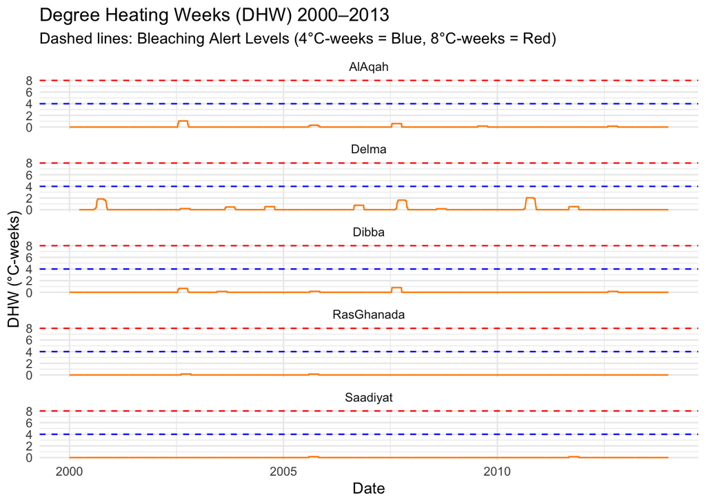

```r
# Converting Site to factor for ordering
dhw <- dhw %>%
  mutate(Site = as.factor(Site))

# Plot: DHW time series with alert thresholds
ggplot(dhw, aes(x = date1, y = dhw)) +
  geom_line(color = "darkorange") +
  geom_hline(yintercept = 4, linetype = "dashed", color = "blue") +
  geom_hline(yintercept = 8, linetype = "dashed", color = "red") +
  facet_wrap(~ Site, scales = "free_y", ncol = 1) +
  labs(
    title = "Degree Heating Weeks (DHW) 2000–2013",
    subtitle = "Dashed lines: Bleaching Alert Levels (4°C-weeks = Blue, 8°C-weeks = Red)",
    x = "Date",
    y = "DHW (°C-weeks)"
  ) +
  theme_minimal()
```

There is not a lot of variation in dhw, with most daily values throughout most years being zero. This is because for DWH at least, the reference period defining the threshold had generally greater temperatures compared to the period between 2000 and 2013.

The plot below shows the mean monthly temperature (MMT) within each year at each site. The red dashed line indicates the the maximum MMT and the blue dashed line the minimum MMT across all years at that site. The filled lines are the lowess fits illustrating the temporal trend in the data for the maximum MMT (red) and minimum MMT (blue). There are few dhw values > 0 in our dataset because there is a general trend that years (2000-2013) experienced lower maxmimum MMT compared to the reference period (1985-1995).

This plot also illustrates that in winter there is not as clear a temporal signal in minimum MMT, but there is arguably a small downtrend at a couple of sites.

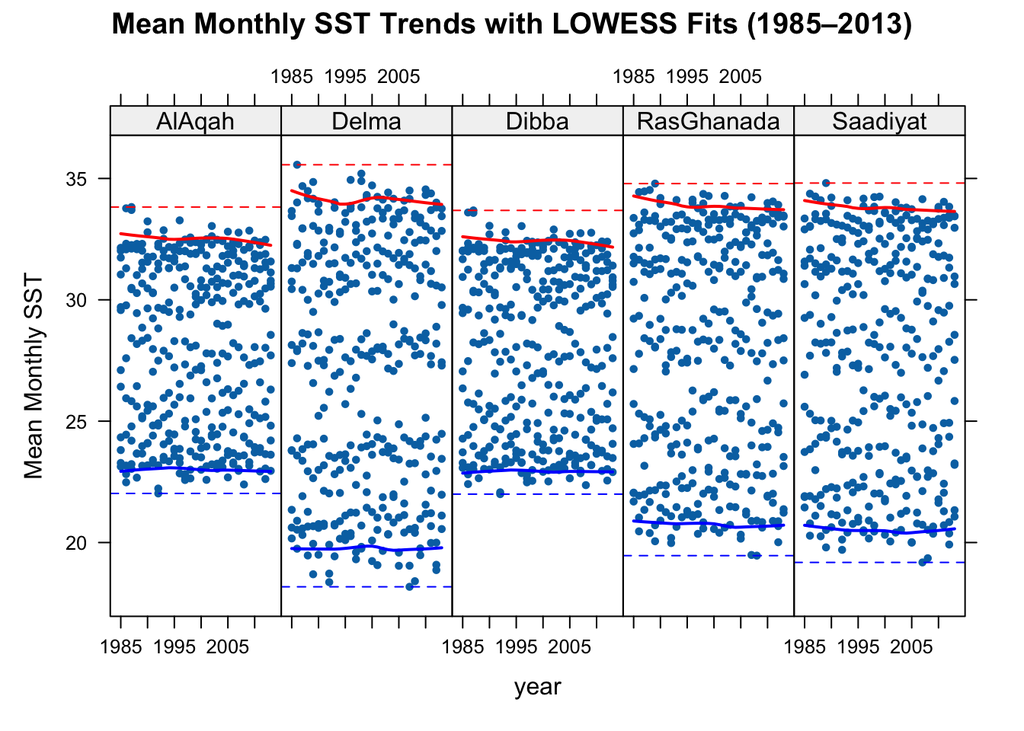

Lets also calculate degree cooling weeks (DCW), where like DHW, the accumulated cold stress over a rolling 12-week (84-day) window is calculated, where daily sea surface temperature (SST) is at least 1°C below a site-specific cold threshold, and the excess cold is summed and expressed in °C-weeks

```r
mmtdata_cool <- temp1 %>%
  tidyr::gather("Site", "sst", 2:all_of(g_num)) %>%
  #dplyr::filter(date1 < "2013-12-31") %>% #define past
  dplyr::filter(date1 >= "1985-01-01" & date1 <= "1995-12-31") %>% #define past
  dplyr::mutate(month = month(date1),
                year = year(date1)) %>%
  dplyr::group_by(Site, year, month) %>%
  dplyr::summarise(avg = mean(sst)) %>% #obtain mthly avgs
  dplyr::group_by(Site, year) %>%
  dplyr::summarise(mmmt = min(avg)) %>% #obtain max mthly avg each year over this period
  dplyr::group_by(Site) %>%
  dplyr::summarise(mmmt = mean(mmmt)) #average this value as threshold for DHW

dhw_calc_12 <- tibbletime::rollify(sum, window = 84)

### observation period, hotspot & dhw calc
dhw_cool <- temp1 %>%
  tidyr::gather("Site", "sst", 2:all_of(g_num)) %>%
  dplyr::filter(date1 >= "2000-01-01" & date1 <= "2013-12-31") %>% #define present
  dplyr::mutate(month = month(date1)) %>%
  dplyr::full_join(mmtdata_cool, by = "Site") %>%
  dplyr::mutate(hspt = sst - mmmt,
                hsptm = ifelse(hspt <= -1, hspt, 0),
                dcw = dhw_calc_12(hsptm)*(1/7)) %>% #hotspot based on less than 1 degree
  dplyr::select(-month, -hsptm)

### again, because we need a summary of dhw by year, we can simply sum all DHW within each year as a yearly metric of total heat stress that year.
dhwm_cool <- dhw_cool %>%
  dplyr::mutate(year = year(date1)) %>%
  dplyr::group_by(Site, year) %>%
  dplyr::summarise(cummu_dcwm = sum(dcw, na.rm = TRUE))
```

And a plot of DCW values over time:

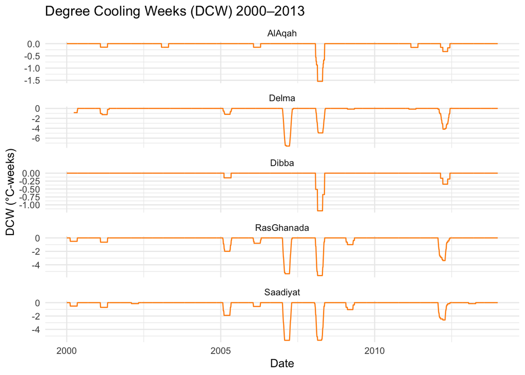

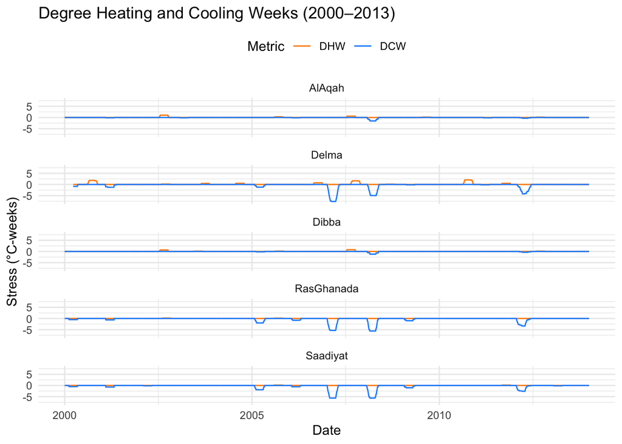

Let’s merge these DHW/DCW summaries with the existing year summaries

```r
# Ensure site key matches your merges
dhwm_merge <- dhwm %>%
  mutate(site = factor(Site)) %>%
  select(site, year, cummu_dhwm)

dcwm_merge <- dhwm_cool %>%
  mutate(site = factor(Site)) %>%
  select(site, year, cummu_dcwm)

# Add to test
test <- test %>%
  left_join(dhwm_merge,  by = c("site","year")) %>%
  left_join(dcwm_merge,  by = c("site","year"))

str(test)
```

```
## 'data.frame':    768 obs. of  45 variables:
##  $ year        : num  2000 2000 2000 2000 2000 2000 2000 2000 2000 2000 ...
##  $ site        : Factor w/ 5 levels "AlAqah","Delma",..: 1 1 3 3 3 3 4 4 4 4 ...
##  $ colony      : chr  "ala12" "ala12" "dib01" "dib01" ...
##  $ track       : chr  "t1" "t2" "t1" "t2" ...
##  $ sample      : chr  "ala12_t1" "ala12_t2" "dib01_t1" "dib01_t2" ...
##  $ calc        : num  0.797 1.007 0.956 0.526 0.94 ...
##  $ extension   : num  0.656 0.57 0.747 0.378 0.817 ...
##  $ density     : num  1.53 1.4 1.28 1.39 1.15 ...
##  $ hdbands     : int  0 0 0 0 0 0 0 0 0 0 ...
##  $ partmort    : int  0 0 0 0 0 0 0 0 0 0 ...
##  $ height      : num  13.5 13.5 NA NA 14 14 7.5 7.5 12 12 ...
##  $ dia         : int  23 23 NA NA 28 28 14 14 16 16 ...
##  $ Site.x      : Factor w/ 5 levels "AlAqah","Delma",..: 1 1 3 3 3 3 4 4 4 4 ...
##  $ WtmaxM      : num  24.1 24.1 24 24 24 ...
```

[output cut: 31 more lines]

### 1.1.5 Current Speed Summaries

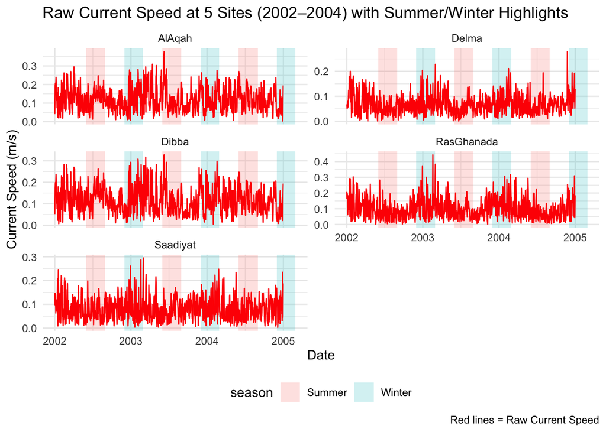

```r
# Load required libraries
library(ggplot2)
library(dplyr)
library(tidyr)
library(lubridate)
library(zoo)   # for na.approx() if needed

# === Load and clean raw current speed data ===
cursp <- read.csv("rawdata/hycom_current_speed_mod.csv")

# Remove rows with missing values
cursp$tf <- complete.cases(cursp)
cursp <- subset(cursp, tf == "TRUE")

# Format date column (assuming cursp$date exists in format "dd/mm/yy")
cursp$date1 <- as.Date(cursp$date, "%d/%m/%y")

# Standardize month ordering
cursp$month <- factor(cursp$month,
                      levels = c("JAN", "FEB", "MAR", "APR", "MAY", "JUN",
                                 "JUL", "AUG", "SEP", "OCT", "NOV", "DEC"))

# === Prepare the raw current speed columns ===
# Assume the raw current speed columns are in positions 4 to 8.
# (Check your data to be sure these indices are correct.)
cursp1 <- cursp[, c(4:8)]
colnames(cursp1) <- paste0(colnames(cursp1), ".raw")

# === Combine key metadata with the raw current speed columns ===
# IMPORTANT: Explicitly include the date1 column so that it is available later.
# Here, we use column names rather than indices.
meta_columns <- c("Time", "date", "Year", "month", "season", "date1")
cursp <- cbind(cursp[, meta_columns], cursp1)

# Optionally: Remove initial rows (if needed to align with prior smoothing)
cursp <- cursp[14:nrow(cursp), ]

# === Reshape data to long format for plotting ===
# We only reshape the columns ending with ".raw" so that date1 and other metadata remain intact.
cursplong <- cursp %>%
  pivot_longer(
    cols = ends_with(".raw"),
    names_to = "Site",
    values_to = "raw"
  ) %>%
  # Remove the ".raw" part from the Site name
  mutate(Site = sub("\\.raw", "", Site))

# === Filter for a 3-year period (adjust years as needed) ===
cursplong <- filter(cursplong, Year >= 2002 & Year <= 2004)

# === Define seasonal shading (Northern Persian Gulf summer and winter) ===
season_boxes <- data.frame(
  start = as.Date(c("2002-06-01", "2002-12-01", "2003-06-01", "2003-12-01", "2004-06-01", "2004-12-01")),
  end   = as.Date(c("2002-08-31", "2003-02-28", "2003-08-31", "2004-02-29", "2004-08-31", "2005-02-28")),
  season = rep(c("Summer", "Winter"), 3)
)

# === Plot raw current speed per site with seasonal highlights ===
ggplot() +
  # Add seasonal shading (semi-transparent)
  geom_rect(data = season_boxes,
            aes(xmin = start, xmax = end, ymin = -Inf, ymax = Inf, fill = season),
            alpha = 0.2, inherit.aes = FALSE) +

  # Plot the raw current speed (red lines)
  geom_line(data = cursplong, aes(x = date1, y = raw), color = "red") +

  # Facet the plot by Site in 2 columns; each site gets its own panel
  facet_wrap(~ Site, ncol = 2, scales = "free_y") +

  # Add titles and labels
  labs(
    title = "Raw Current Speed at 5 Sites (2002–2004) with Summer/Winter Highlights",
    x = "Date", y = "Current Speed (m/s)",
    caption = "Red lines = Raw Current Speed"
  ) +
  theme_minimal() +
  theme(legend.position = "bottom")
```

It can be seen here that site-based and seasonal patterns in daily current speed are far less pronounced than with SST data. There does appear to be more daily variation in the winter months compared to summer months. Will will also add a moving average to this data to smooth out some of the noise from daily variation. Since these data are far more volatile than SST data, we will use a Zero Lag Exponential Moving Average (ZLEMA) for current speed data over a shorted time period (14 days) than was used for the SST data. We produce the same plot with the smoothed trends:

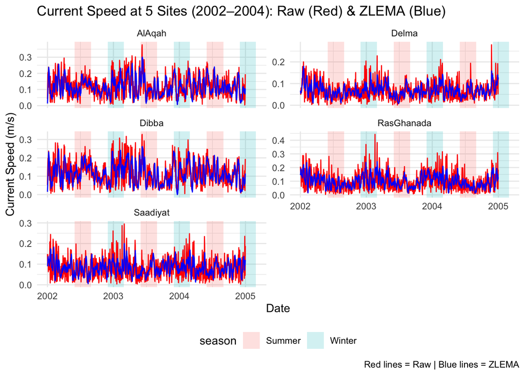

```r
# === Add ZLEMA smoothed data (14-day) ===
cursp$Delma.MA <- ZLEMA(cursp$Delma.raw, n = 14)
cursp$RasGhanada.MA <- ZLEMA(cursp$RasGhanada.raw, n = 14)
cursp$Saadiyat.MA <- ZLEMA(cursp$Saadiyat.raw, n = 14)
cursp$AlAqah.MA <- ZLEMA(cursp$AlAqah.raw, n = 14)
cursp$Dibba.MA <- ZLEMA(cursp$Dibba.raw, n = 14)

# Optional: remove early rows with NA due to smoothing window
cursp <- cursp[14:nrow(cursp), ]

# === Reshape data to long format ===
cursplong <- cursp %>%
  pivot_longer(
    cols = ends_with(".raw") | ends_with(".MA"),
    names_to = c("Site", "Type"),
    names_sep = "\\.",
    values_to = "value"
  ) %>%
  pivot_wider(names_from = Type, values_from = value)  # gets columns "raw" and "MA"

# === Filter for 3-year window (2002–2004) ===
cursplong <- filter(cursplong, Year >= 2002 & Year <= 2004)

# === Define seasonal shading (Northern Persian Gulf) ===
season_boxes <- data.frame(
  start = as.Date(c("2002-06-01", "2002-12-01", "2003-06-01", "2003-12-01", "2004-06-01", "2004-12-01")),
  end   = as.Date(c("2002-08-31", "2003-02-28", "2003-08-31", "2004-02-29", "2004-08-31", "2005-02-28")),
  season = rep(c("Summer", "Winter"), 3)
)

# === Plot raw + ZLEMA current speed, faceted by site ===
ggplot() +
  # Seasonal highlight
  geom_rect(data = season_boxes,
            aes(xmin = start, xmax = end, ymin = -Inf, ymax = Inf, fill = season),
            alpha = 0.2, inherit.aes = FALSE) +

  # Raw data line
  geom_line(data = cursplong, aes(x = date1, y = raw), color = "red") +

  # ZLEMA smoothed line
  geom_line(data = cursplong, aes(x = date1, y = MA), color = "blue") +

  # Facet by site
  facet_wrap(~ Site, ncol = 2, scales = "free_y") +

  # Labels and theme
  labs(
    title = "Current Speed at 5 Sites (2002–2004): Raw (Red) & ZLEMA (Blue)",
    x = "Date", y = "Current Speed (m/s)",
    caption = "Red lines = Raw | Blue lines = ZLEMA"
  ) +
  theme_minimal() +
  theme(legend.position = "bottom")
```

Test of the final code and merging:

```r
### Whole year summaries using ddply
library(plyr)

delt <- ddply(cursp, .(Year), summarise,
              csmaxM = max(Delma.MA), csminM = min(Delma.MA),
              csavM = mean(Delma.MA), cssdM = sd(Delma.MA))

ras <- ddply(cursp, .(Year), summarise,
             csmaxM = max(RasGhanada.MA), csminM = min(RasGhanada.MA),
             csavM = mean(RasGhanada.MA), cssdM = sd(RasGhanada.MA))

saa <- ddply(cursp, .(Year), summarise,
             csmaxM = max(Saadiyat.MA), csminM = min(Saadiyat.MA),
             csavM = mean(Saadiyat.MA), cssdM = sd(Saadiyat.MA))

ala <- ddply(cursp, .(Year), summarise,
             csmaxM = max(AlAqah.MA), csminM = min(AlAqah.MA),
             csavM = mean(AlAqah.MA), cssdM = sd(AlAqah.MA))

dib <- ddply(cursp, .(Year), summarise,
             csmaxM = max(Dibba.MA), csminM = min(Dibba.MA),
             csavM = mean(Dibba.MA), cssdM = sd(Dibba.MA))

# Reuse your ZLEMA’d 'cursp' and long 'cursplong'
# Join SST window flags (CMA_min/max) from temp1 into current-speed long data
cursplong1 <- cursp %>%
  tidyr::pivot_longer(
    cols = matches("\\.(raw|MA)$"),
    names_to = c("Site","Type"),
    names_sep = "\\.",
    values_to = "value"
  ) %>%
  tidyr::pivot_wider(names_from = Type, values_from = value) %>%
  dplyr::mutate(Site = factor(Site)) %>%
  dplyr::left_join(
    sst_windows,                      # <<— use the saved copy
    by = c("date1","Site","Year","month")
  ) %>%
  dplyr::mutate(
    winteryear = dplyr::if_else(month == "DEC" & CMA_min == 1, Year + 1L, Year)
  )

wcursp <- cursplong1 %>% filter(CMA_min == 1)
scursp <- cursplong1 %>% filter(CMA_max == 1)

get_seasonal_summary <- function(df, group_var, prefix){
  df %>%
    dplyr::group_by(.data[[group_var]], Site) %>%
    dplyr::summarise(
      maxM = max(MA,  na.rm = TRUE),
      minM = min(MA,  na.rm = TRUE),
      avM  = mean(MA, na.rm = TRUE),
      sdM  = sd(MA,   na.rm = TRUE),
      maxR = max(raw, na.rm = TRUE),
      minR = min(raw, na.rm = TRUE),
      avR  = mean(raw,na.rm = TRUE),
      sdR  = sd(raw,  na.rm = TRUE),
      .groups = "drop"
    ) %>%
    dplyr::mutate(site = factor(Site)) %>%
    dplyr::select(-Site) %>%
    dplyr::mutate(year = .data[[group_var]]) %>%
    dplyr::select(-dplyr::all_of(group_var)) %>%
    dplyr::rename_with(~ paste0(prefix, .), -c(year, site))
}

Wcssumall <- get_seasonal_summary(wcursp, "winteryear", "Wcs") %>%
  mutate(WcsrangeM = WcsmaxM - WcsminM,
         WcsrangeR = WcsmaxR - WcsminR)

Scssumall <- get_seasonal_summary(scursp, "Year", "Scs") %>%
  mutate(ScsrangeM = ScsmaxM - ScsminM)

# Merge into test
test <- test %>%
  left_join(Wcssumall, by = c("year","site")) %>%
  left_join(Scssumall, by = c("year","site"))
```

We can now add further colony attributes (minimum age defined at the first back calculated calendar year with registered growth metrics) and whether the sites are in the Persian Gulf (gulf) or the Gulf of Oman (oman)

```r
minage <- read.csv("rawdata/minage.csv") %>% select(colony, minage = 4)

test <- test %>%
  left_join(minage, by = "colony") %>%
  mutate(gulf = if_else(site %in% c("AlAqah","Dibba"), "oman", "gulf"))
str(test)
```

```
## 'data.frame':    768 obs. of  66 variables:
##  $ year        : num  2000 2000 2000 2000 2000 2000 2000 2000 2000 2000 ...
##  $ site        : Factor w/ 5 levels "AlAqah","Delma",..: 1 1 3 3 3 3 4 4 4 4 ...
##  $ colony      : chr  "ala12" "ala12" "dib01" "dib01" ...
##  $ track       : chr  "t1" "t2" "t1" "t2" ...
##  $ sample      : chr  "ala12_t1" "ala12_t2" "dib01_t1" "dib01_t2" ...
##  $ calc        : num  0.797 1.007 0.956 0.526 0.94 ...
##  $ extension   : num  0.656 0.57 0.747 0.378 0.817 ...
##  $ density     : num  1.53 1.4 1.28 1.39 1.15 ...
##  $ hdbands     : int  0 0 0 0 0 0 0 0 0 0 ...
##  $ partmort    : int  0 0 0 0 0 0 0 0 0 0 ...
##  $ height      : num  13.5 13.5 NA NA 14 14 7.5 7.5 12 12 ...
##  $ dia         : int  23 23 NA NA 28 28 14 14 16 16 ...
##  $ Site.x      : Factor w/ 5 levels "AlAqah","Delma",..: 1 1 3 3 3 3 4 4 4 4 ...
##  $ WtmaxM      : num  24.1 24.1 24 24 24 ...
```

[output cut: 52 more lines]

### 1.1.6 Creating a lagged dataset

In order to investigate lag effects (if the environmental metrics in the previous year affected growth the following year) we make a lagged version of the dataframe

```r
lag1 <- function(df){ df %>% mutate(year = year + 1L) }

Wtsumallm1   <- lag1(Wtsumall)
Stsumallm1   <- lag1(Stsumall)
wintrocfinm1 <- lag1(wintrocfin)
summrocfinm1 <- lag1(summrocfin)
Wcssumallm1  <- lag1(Wcssumall)
Scssumallm1  <- lag1(Scssumall)
dhwm_m1      <- lag1(dhwm_merge)
dcwm_m1      <- lag1(dcwm_merge)

testlag1 <- onyr %>%
  mutate(site = factor(site)) %>%
  left_join(Wtsumallm1,   by = c("year","site")) %>%
  left_join(Stsumallm1,   by = c("year","site")) %>%
  left_join(wintrocfinm1, by = c("year","site")) %>%
  left_join(summrocfinm1, by = c("year","site")) %>%
  left_join(Wcssumallm1,  by = c("year","site")) %>%
  left_join(Scssumallm1,  by = c("year","site")) %>%
  left_join(dhwm_m1,      by = c("year","site")) %>%
  left_join(dcwm_m1,      by = c("year","site")) %>%
  left_join(minage,       by = "colony") %>%
  mutate(gulf = if_else(site %in% c("AlAqah","Dibba"), "oman", "gulf"))
```

### 1.1.7 Joining ENV with growth data and getting complete cases

Here we combine all of our summarized environmental data with the growth data and remove any incomplete cases from the datasets so intial models are fit with all data with complete cases

```r
# keep only complete rows for modeling
# define shared predictor set once
base_preds <- c(
  "colony","year","Site","track","sample",
  "height","dia",
  # Summer/Winter SST stats (raw):
  "StavR","WtavR","WtsdR","StsdR",
  # SST rates of change:
  "winSlope","sumSlope","ccoldday","warmday",
  # Currents (raw):
  "WcsavR","WcssdR","ScsavR","ScssdR",
  # Thermal stress:
  "cummu_dhwm","cummu_dcwm",
  # Region:
  "gulf"
)

# --- build each analysis df independently (no global complete.cases) ---
testcalc <- test %>%
  dplyr::select(dplyr::any_of(c(base_preds, "calc"))) %>%
  tidyr::drop_na(calc) %>%                     # need outcome present
  tidyr::drop_na(dplyr::any_of(base_preds))    # need predictors present

testex <- test %>%
  dplyr::select(dplyr::any_of(c(base_preds, "extension"))) %>%
  tidyr::drop_na(extension) %>%
  tidyr::drop_na(dplyr::any_of(base_preds))

testden <- test %>%
  dplyr::select(dplyr::any_of(c(base_preds, "density"))) %>%
  tidyr::drop_na(density) %>%
  tidyr::drop_na(dplyr::any_of(base_preds))
```

We can now look at the complete cases that we have for each growth variable.

Extension:

```r
str(testex)
```

```
## 'data.frame':    709 obs. of  23 variables:
##  $ colony    : chr  "ala12" "ala12" "dib04" "dib04" ...
##  $ year      : num  2000 2000 2000 2000 2000 2000 2000 2000 2000 2000 ...
##  $ Site      : chr  "AlAqah" "AlAqah" "Dibba" "Dibba" ...
##  $ track     : chr  "t1" "t2" "t1" "t2" ...
##  $ sample    : chr  "ala12_t1" "ala12_t2" "dib04_t1" "dib04_t2" ...
##  $ height    : num  13.5 13.5 14 14 7.5 7.5 12 12 9 14 ...
##  $ dia       : int  23 23 28 28 14 14 16 16 16 22 ...
##  $ StavR     : num  32.3 32.3 32.3 32.3 33.4 ...
##  $ WtavR     : num  23.1 23.1 23 23 21 ...
##  $ WtsdR     : num  0.424 0.424 0.417 0.417 0.657 ...
##  $ StsdR     : num  0.545 0.545 0.432 0.432 0.451 ...
##  $ winSlope  : num  0.0959 0.0959 0.0938 0.0938 0.1171 ...
##  $ sumSlope  : num  -0.0338 -0.0338 -0.0371 -0.0371 -0.0316 ...
##  $ ccoldday  : int  42 42 42 42 42 42 42 42 42 42 ...
##  $ warmday   : int  301 301 301 301 290 290 290 290 290 290 ...
##  $ WcsavR    : num  0.148 0.148 0.148 0.148 0.147 ...
##  $ WcssdR    : num  0.0753 0.0753 0.074 0.074 0.0917 ...
##  $ ScsavR    : num  0.185 0.185 0.16 0.16 0.109 ...
##  $ ScssdR    : num  0.0776 0.0776 0.062 0.062 0.031 ...
##  $ cummu_dhwm: num  0 0 0 0 0 0 0 0 0 0 ...
##  $ cummu_dcwm: num  0 0 0 0 -42.6 ...
##  $ gulf      : chr  "oman" "oman" "oman" "oman" ...
##  $ extension : num  0.656 0.57 0.817 1.1 0.474 ...
```

Density:

```r
str(testden)
```

```
## 'data.frame':    711 obs. of  23 variables:
##  $ colony    : chr  "ala12" "ala12" "dib04" "dib04" ...
##  $ year      : num  2000 2000 2000 2000 2000 2000 2000 2000 2000 2000 ...
##  $ Site      : chr  "AlAqah" "AlAqah" "Dibba" "Dibba" ...
##  $ track     : chr  "t1" "t2" "t1" "t2" ...
##  $ sample    : chr  "ala12_t1" "ala12_t2" "dib04_t1" "dib04_t2" ...
##  $ height    : num  13.5 13.5 14 14 7.5 7.5 12 12 9 14 ...
##  $ dia       : int  23 23 28 28 14 14 16 16 16 22 ...
##  $ StavR     : num  32.3 32.3 32.3 32.3 33.4 ...
##  $ WtavR     : num  23.1 23.1 23 23 21 ...
##  $ WtsdR     : num  0.424 0.424 0.417 0.417 0.657 ...
##  $ StsdR     : num  0.545 0.545 0.432 0.432 0.451 ...
##  $ winSlope  : num  0.0959 0.0959 0.0938 0.0938 0.1171 ...
##  $ sumSlope  : num  -0.0338 -0.0338 -0.0371 -0.0371 -0.0316 ...
##  $ ccoldday  : int  42 42 42 42 42 42 42 42 42 42 ...
##  $ warmday   : int  301 301 301 301 290 290 290 290 290 290 ...
##  $ WcsavR    : num  0.148 0.148 0.148 0.148 0.147 ...
##  $ WcssdR    : num  0.0753 0.0753 0.074 0.074 0.0917 ...
##  $ ScsavR    : num  0.185 0.185 0.16 0.16 0.109 ...
##  $ ScssdR    : num  0.0776 0.0776 0.062 0.062 0.031 ...
##  $ cummu_dhwm: num  0 0 0 0 0 0 0 0 0 0 ...
##  $ cummu_dcwm: num  0 0 0 0 -42.6 ...
##  $ gulf      : chr  "oman" "oman" "oman" "oman" ...
##  $ density   : num  1.53 1.4 1.15 1.21 1.48 ...
```

Calcification:

```r
str(testcalc)
```

```
## 'data.frame':    714 obs. of  23 variables:
##  $ colony    : chr  "ala12" "ala12" "dib04" "dib04" ...
##  $ year      : num  2000 2000 2000 2000 2000 2000 2000 2000 2000 2000 ...
##  $ Site      : chr  "AlAqah" "AlAqah" "Dibba" "Dibba" ...
##  $ track     : chr  "t1" "t2" "t1" "t2" ...
##  $ sample    : chr  "ala12_t1" "ala12_t2" "dib04_t1" "dib04_t2" ...
##  $ height    : num  13.5 13.5 14 14 7.5 7.5 12 12 11 11 ...
##  $ dia       : int  23 23 28 28 14 14 16 16 18 18 ...
##  $ StavR     : num  32.3 32.3 32.3 32.3 33.4 ...
##  $ WtavR     : num  23.1 23.1 23 23 21 ...
##  $ WtsdR     : num  0.424 0.424 0.417 0.417 0.657 ...
##  $ StsdR     : num  0.545 0.545 0.432 0.432 0.451 ...
##  $ winSlope  : num  0.0959 0.0959 0.0938 0.0938 0.1171 ...
##  $ sumSlope  : num  -0.0338 -0.0338 -0.0371 -0.0371 -0.0316 ...
##  $ ccoldday  : int  42 42 42 42 42 42 42 42 42 42 ...
##  $ warmday   : int  301 301 301 301 290 290 290 290 290 290 ...
##  $ WcsavR    : num  0.148 0.148 0.148 0.148 0.147 ...
##  $ WcssdR    : num  0.0753 0.0753 0.074 0.074 0.0917 ...
##  $ ScsavR    : num  0.185 0.185 0.16 0.16 0.109 ...
##  $ ScssdR    : num  0.0776 0.0776 0.062 0.062 0.031 ...
##  $ cummu_dhwm: num  0 0 0 0 0 0 0 0 0 0 ...
##  $ cummu_dcwm: num  0 0 0 0 -42.6 ...
##  $ gulf      : chr  "oman" "oman" "oman" "oman" ...
##  $ calc      : num  0.797 1.007 0.94 1.335 0.7 ...
```

### 1.1.8 Counts of Extreme temperature days per year

A final metric to add for each dataset is the number of days per year the SST is above or below thresholds. These thresholds can be arbitrarily defined. We will use the number of days each year at each site where temp is above the 90th & 95th and below the 10th & 5th percentile of temperatures in the persian gulf in the 15 years between 1985 and 2000.

```r
# Ensure 'gulf' flag exists (Gulf vs Oman)
if (!"gulf" %in% names(templong)) {
  templong <- templong %>%
    mutate(gulf = if_else(Site %in% c("AlAqah","Dibba"), "oman", "gulf"))
}

# ----- Compute dynamic thresholds from baseline: 1985–2000, Gulf only -----
# thresholds as before...
quantiles <- templong %>%
  dplyr::filter(Year < 2001, gulf == "gulf") %>%
  dplyr::summarise(
    q05 = stats::quantile(raw, 0.05, na.rm = TRUE),
    q10 = stats::quantile(raw, 0.10, na.rm = TRUE),
    q90 = stats::quantile(raw, 0.90, na.rm = TRUE),
    q95 = stats::quantile(raw, 0.95, na.rm = TRUE)
  )

q05 <- quantiles$q05; q10 <- quantiles$q10; q90 <- quantiles$q90; q95 <- quantiles$q95

day95 <- templong %>%
  dplyr::group_by(Year, Site) %>%
  dplyr::summarise(count95 = sum(raw > q95, na.rm = TRUE), .groups = "drop")

day90 <- templong %>%
  dplyr::group_by(Year, Site) %>%
  dplyr::summarise(count90 = sum(raw > q90, na.rm = TRUE), .groups = "drop")

day10 <- templong %>%
  dplyr::group_by(Year, Site) %>%
  dplyr::summarise(count10 = sum(raw < q10, na.rm = TRUE), .groups = "drop")

day05 <- templong %>%
  dplyr::group_by(Year, Site) %>%
  dplyr::summarise(count05 = sum(raw < q05, na.rm = TRUE), .groups = "drop")

merge_q <- function(df){
  df %>%
    dplyr::mutate(Site = as.character(Site)) %>%   # ensure join type matches
    dplyr::left_join(day95, by = c("year" = "Year","Site")) %>%
    dplyr::left_join(day90, by = c("year" = "Year","Site")) %>%
    dplyr::left_join(day10, by = c("year" = "Year","Site")) %>%
    dplyr::left_join(day05, by = c("year" = "Year","Site")) %>%
    dplyr::mutate(dplyr::across(c(count95,count90,count10,count05),
                                ~tidyr::replace_na(., 0L)))
}

testcalc <- merge_q(testcalc)
testex   <- merge_q(testex)
testden  <- merge_q(testden)
```

### 1.1.9 Adding coral size data

A final addition is that since already know that how coral respond to environmental conditions is likely to be conditional on the size of t the colony, we need to back calculate the height of each colony within each year, given the final measure of colony height that we have from our coral slices.

```r
# --- Add Bheight from "Bheights" sheet to testex / testden / testcalc ---

library(readxl)
library(dplyr)
library(stringr)

# 1) Read Bheight data from the "Bheights" sheet
bheights <- readxl::read_excel("rawdata/Bheights.xlsx", sheet = "Bheights") %>%
  dplyr::rename_with(~ tolower(stringr::str_trim(.x))) %>%
  dplyr::rename(Bheight = bheight) %>%
  dplyr::mutate(
    colony = as.character(colony) %>% stringr::str_trim(),
    year   = as.integer(year)
  ) %>%
  dplyr::select(colony, year, Bheight) %>%
  dplyr::distinct()

# 2) Function to add Bheight to a dataset (if it exists)
add_bheight <- function(df_name) {
  if (!exists(df_name, inherits = TRUE)) return(invisible(NULL))

  df <- get(df_name, inherits = TRUE) %>%
    dplyr::mutate(
      colony = as.character(colony) %>% stringr::str_trim(),
      year   = as.integer(year)
    ) %>%
    dplyr::left_join(bheights, by = c("colony", "year"))

  assign(df_name, df, inherits = TRUE)
  message(df_name, ": added Bheight to ", sum(!is.na(df$Bheight)), " rows.")
}

# 3) Apply to all datasets
for (nm in c("testex", "testden", "testcalc")) add_bheight(nm)

# 4) (Optional) Save updated data
if (exists("testex"))  utils::write.csv(testex,  "processeddata/testex.csv",  row.names = FALSE)
if (exists("testden")) utils::write.csv(testden, "processeddata/testden.csv", row.names = FALSE)
if (exists("testcalc"))utils::write.csv(testcalc,"processeddata/testcalc.csv",row.names = FALSE)

message("✅ Bheight successfully added to all datasets.")
```

### 1.1.10 Final datasets for analysis

Extension:

```r
str(testex)
```

```
## 'data.frame':    709 obs. of  28 variables:
##  $ colony    : chr  "ala12" "ala12" "dib04" "dib04" ...
##  $ year      : int  2000 2000 2000 2000 2000 2000 2000 2000 2000 2000 ...
##  $ Site      : chr  "AlAqah" "AlAqah" "Dibba" "Dibba" ...
##  $ track     : chr  "t1" "t2" "t1" "t2" ...
##  $ sample    : chr  "ala12_t1" "ala12_t2" "dib04_t1" "dib04_t2" ...
##  $ height    : num  13.5 13.5 14 14 7.5 7.5 12 12 9 14 ...
##  $ dia       : int  23 23 28 28 14 14 16 16 16 22 ...
##  $ StavR     : num  32.3 32.3 32.3 32.3 33.4 ...
##  $ WtavR     : num  23.1 23.1 23 23 21 ...
##  $ WtsdR     : num  0.424 0.424 0.417 0.417 0.657 ...
##  $ StsdR     : num  0.545 0.545 0.432 0.432 0.451 ...
##  $ winSlope  : num  0.0959 0.0959 0.0938 0.0938 0.1171 ...
##  $ sumSlope  : num  -0.0338 -0.0338 -0.0371 -0.0371 -0.0316 ...
##  $ ccoldday  : int  42 42 42 42 42 42 42 42 42 42 ...
##  $ warmday   : int  301 301 301 301 290 290 290 290 290 290 ...
##  $ WcsavR    : num  0.148 0.148 0.148 0.148 0.147 ...
##  $ WcssdR    : num  0.0753 0.0753 0.074 0.074 0.0917 ...
##  $ ScsavR    : num  0.185 0.185 0.16 0.16 0.109 ...
##  $ ScssdR    : num  0.0776 0.0776 0.062 0.062 0.031 ...
##  $ cummu_dhwm: num  0 0 0 0 0 0 0 0 0 0 ...
##  $ cummu_dcwm: num  0 0 0 0 -42.6 ...
##  $ gulf      : chr  "oman" "oman" "oman" "oman" ...
##  $ extension : num  0.656 0.57 0.817 1.1 0.474 ...
##  $ count95   : int  0 0 0 0 3 3 3 3 4 4 ...
##  $ count90   : int  0 0 0 0 19 19 19 19 30 30 ...
##  $ count10   : int  0 0 0 0 21 21 21 21 28 28 ...
##  $ count05   : int  0 0 0 0 6 6 6 6 9 9 ...
##  $ Bheight   : num  4.94 4.94 5.31 5.31 2.15 ...
```

Density:

```r
str(testden)
```

```
## 'data.frame':    711 obs. of  28 variables:
##  $ colony    : chr  "ala12" "ala12" "dib04" "dib04" ...
##  $ year      : int  2000 2000 2000 2000 2000 2000 2000 2000 2000 2000 ...
##  $ Site      : chr  "AlAqah" "AlAqah" "Dibba" "Dibba" ...
##  $ track     : chr  "t1" "t2" "t1" "t2" ...
##  $ sample    : chr  "ala12_t1" "ala12_t2" "dib04_t1" "dib04_t2" ...
##  $ height    : num  13.5 13.5 14 14 7.5 7.5 12 12 9 14 ...
##  $ dia       : int  23 23 28 28 14 14 16 16 16 22 ...
##  $ StavR     : num  32.3 32.3 32.3 32.3 33.4 ...
##  $ WtavR     : num  23.1 23.1 23 23 21 ...
##  $ WtsdR     : num  0.424 0.424 0.417 0.417 0.657 ...
##  $ StsdR     : num  0.545 0.545 0.432 0.432 0.451 ...
##  $ winSlope  : num  0.0959 0.0959 0.0938 0.0938 0.1171 ...
##  $ sumSlope  : num  -0.0338 -0.0338 -0.0371 -0.0371 -0.0316 ...
##  $ ccoldday  : int  42 42 42 42 42 42 42 42 42 42 ...
##  $ warmday   : int  301 301 301 301 290 290 290 290 290 290 ...
##  $ WcsavR    : num  0.148 0.148 0.148 0.148 0.147 ...
##  $ WcssdR    : num  0.0753 0.0753 0.074 0.074 0.0917 ...
##  $ ScsavR    : num  0.185 0.185 0.16 0.16 0.109 ...
##  $ ScssdR    : num  0.0776 0.0776 0.062 0.062 0.031 ...
##  $ cummu_dhwm: num  0 0 0 0 0 0 0 0 0 0 ...
##  $ cummu_dcwm: num  0 0 0 0 -42.6 ...
##  $ gulf      : chr  "oman" "oman" "oman" "oman" ...
##  $ density   : num  1.53 1.4 1.15 1.21 1.48 ...
##  $ count95   : int  0 0 0 0 3 3 3 3 4 4 ...
##  $ count90   : int  0 0 0 0 19 19 19 19 30 30 ...
##  $ count10   : int  0 0 0 0 21 21 21 21 28 28 ...
##  $ count05   : int  0 0 0 0 6 6 6 6 9 9 ...
##  $ Bheight   : num  4.94 4.94 5.31 5.31 2.15 ...
```

Calcification:

```r
str(testcalc)
```

```
## 'data.frame':    714 obs. of  28 variables:
##  $ colony    : chr  "ala12" "ala12" "dib04" "dib04" ...
##  $ year      : int  2000 2000 2000 2000 2000 2000 2000 2000 2000 2000 ...
##  $ Site      : chr  "AlAqah" "AlAqah" "Dibba" "Dibba" ...
##  $ track     : chr  "t1" "t2" "t1" "t2" ...
##  $ sample    : chr  "ala12_t1" "ala12_t2" "dib04_t1" "dib04_t2" ...
##  $ height    : num  13.5 13.5 14 14 7.5 7.5 12 12 11 11 ...
##  $ dia       : int  23 23 28 28 14 14 16 16 18 18 ...
##  $ StavR     : num  32.3 32.3 32.3 32.3 33.4 ...
##  $ WtavR     : num  23.1 23.1 23 23 21 ...
##  $ WtsdR     : num  0.424 0.424 0.417 0.417 0.657 ...
##  $ StsdR     : num  0.545 0.545 0.432 0.432 0.451 ...
##  $ winSlope  : num  0.0959 0.0959 0.0938 0.0938 0.1171 ...
##  $ sumSlope  : num  -0.0338 -0.0338 -0.0371 -0.0371 -0.0316 ...
##  $ ccoldday  : int  42 42 42 42 42 42 42 42 42 42 ...
##  $ warmday   : int  301 301 301 301 290 290 290 290 290 290 ...
##  $ WcsavR    : num  0.148 0.148 0.148 0.148 0.147 ...
##  $ WcssdR    : num  0.0753 0.0753 0.074 0.074 0.0917 ...
##  $ ScsavR    : num  0.185 0.185 0.16 0.16 0.109 ...
##  $ ScssdR    : num  0.0776 0.0776 0.062 0.062 0.031 ...
##  $ cummu_dhwm: num  0 0 0 0 0 0 0 0 0 0 ...
##  $ cummu_dcwm: num  0 0 0 0 -42.6 ...
##  $ gulf      : chr  "oman" "oman" "oman" "oman" ...
##  $ calc      : num  0.797 1.007 0.94 1.335 0.7 ...
##  $ count95   : int  0 0 0 0 3 3 3 3 4 4 ...
##  $ count90   : int  0 0 0 0 19 19 19 19 30 30 ...
##  $ count10   : int  0 0 0 0 21 21 21 21 28 28 ...
##  $ count05   : int  0 0 0 0 6 6 6 6 9 9 ...
##  $ Bheight   : num  4.94 4.94 5.31 5.31 2.15 ...
```

## 1.2 Modelling linear extension

### 1.2.1 Data exploration/checking

Environmental data are processed. We will first check the linear extension data for outliers etc before moving onto model selection, validation and plotting.

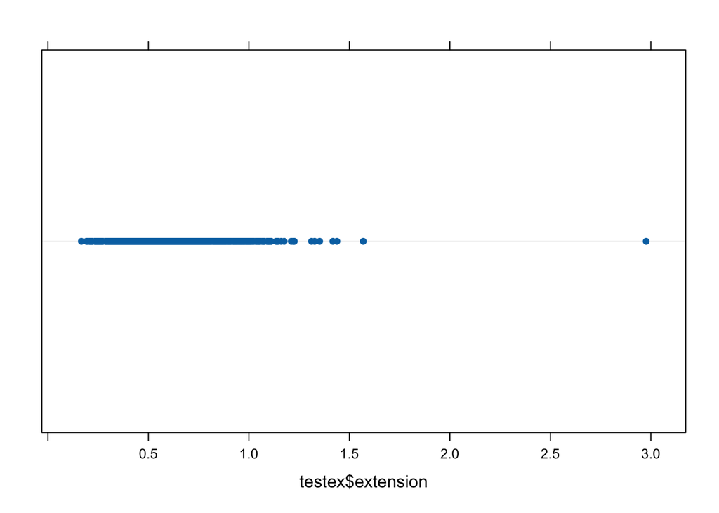

```r
## loading necessary libraries
library(lattice)    # for dotplot()
library(dplyr)
library(tidyr)
library(tidybayes)
library(ggplot2)
library(brms)
library(cmdstanr)   # backend for brms
library(loo)
library(performance)
library(plotly)

## and processed data:
testex <- read.csv("processeddata/testex.csv")
#### checking extension for outliers / measurement errors
dotplot(testex$extension)
```

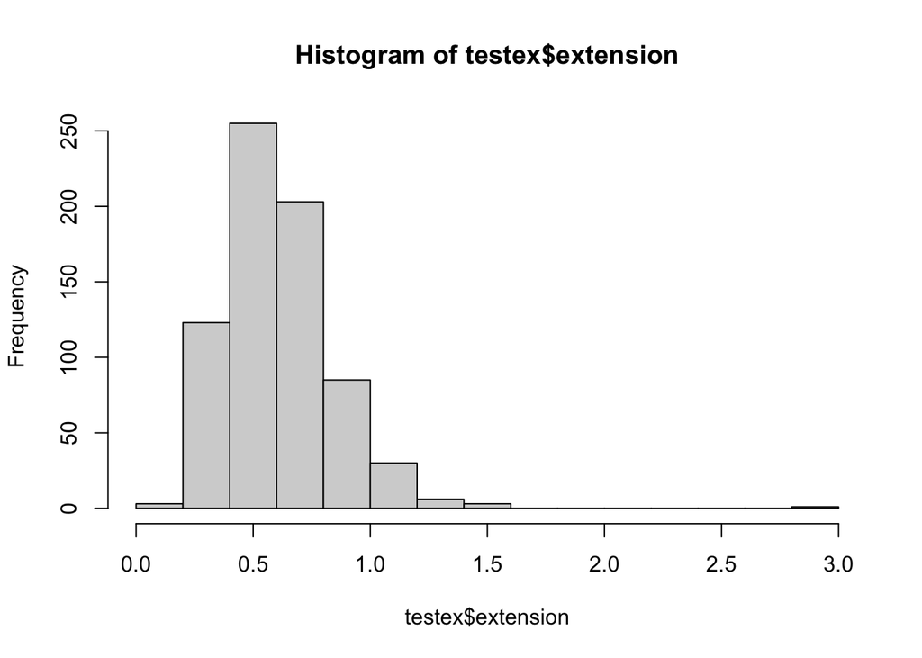

```r
hist(testex$extension)
```

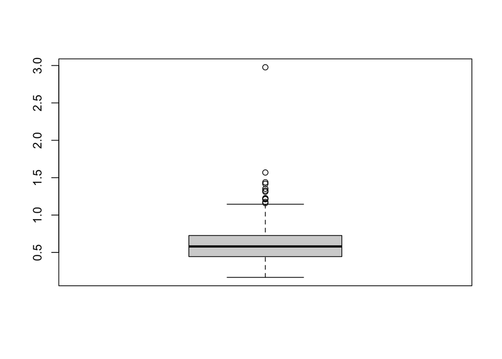

```r
boxplot(testex$extension)
```

We can see that there is a single extension measurement of nearly 3 cms. Considering that generally two measurements of linear extension were taken per colony per year and that this is well outside the range of all other data, it is most likely an error and we will exclude it.

```r
testex <- subset(testex, extension < 2.8)
```

We should look at the explanatory variables we will use to check for structural issues with those.  
We are mostly interested in variables that do not overlap between inside the Arabian gulf (“gulf”) and the Gulf of Oman (“oman” . i.e. outside the Arabian Gulf), because these will be problematic for parameter estimation and interpretation.

Here the explanatory variable codes are:

Bheight: The back calculated height of the colony from the colony nucleus, in that year  
StavR: The average temperature for the 61 hottest days in each year in summer  
StsdR: The standard deviation of temperature for the 61 hottest days in each year in summer  
sumSlope: The rate of change of degrees celcius per day from the hottest day in summer through the following 90 days towards winter  
WtavR: The average temperature for the 61 coldest days in each year in winter  
WtsdR: The standard deviation of temperature for the 61 coldest days in each year in winter  
winSlope: The rate of change of degrees celcius per day from the coldest day in winter through the following 90 days towards summer  
WcsavR: The average current speed for the 61 coldest days in each year in winter

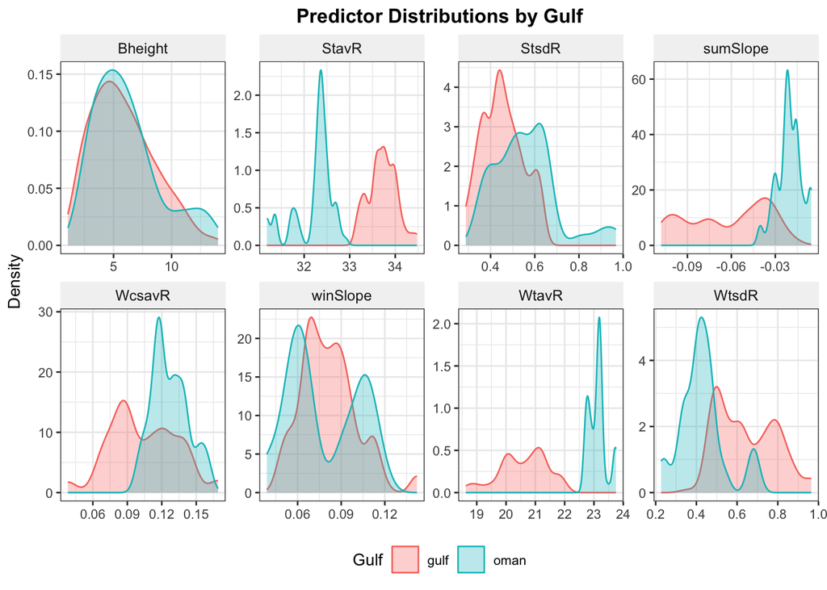

```r
# ============================================================
# Overlayed distributions by Gulf — one facet per variable
# ============================================================

library(ggplot2)
library(dplyr)
library(tidyr)

vars <- c("StavR","WtavR","WtsdR","winSlope","StsdR","sumSlope","WcsavR","Bheight")

plot_data <- testex %>%
  select(all_of(vars), gulf) %>%
  pivot_longer(all_of(vars), names_to = "variable", values_to = "value")

p <- ggplot(plot_data, aes(x = value, fill = gulf, color = gulf)) +
  geom_density(alpha = 0.3, na.rm = TRUE) +      # semi-transparent overlay
  facet_wrap(~ variable, scales = "free", ncol = 4) +  # one panel per var
  labs(x = NULL, y = "Density", fill = "Gulf", color = "Gulf",
       title = "Predictor Distributions by Gulf") +
  theme_bw(base_size = 10) +
  theme(
    legend.position = "bottom",
    plot.title = element_text(size = 12, face = "bold", hjust = 0.5),
    strip.background = element_rect(fill = "grey95", colour = NA),
    strip.text = element_text(size = 9)
  )

print(p)
```

We can see that particularly for the average summer and winter temperatures, there is no overlap inside and outside the gulf. This will require some rescaling and for this we can use z-scores. we will standardize data by within-gulf z-scores. By doing this and and testing for interactions between z-scores and gulf, we can examine within-gulf slopes (i.e. the effect of temperature on extension within each gulf’s observed range (no extrapolation) and interaction terms: how those slopes may differ between gulfs. We will also standardize all other variables by their grand mean, to help with MCMC convergence.

```r
testex <- testex %>%
  group_by(gulf) %>%
  mutate(
    StavR_zg = (StavR - mean(StavR, na.rm=TRUE)) / sd(StavR, na.rm=TRUE),
    WtavR_zg = (WtavR - mean(WtavR, na.rm=TRUE)) / sd(WtavR, na.rm=TRUE),
  ) %>%
  ungroup() %>%
  mutate(
    WtsdR_c = WtsdR - mean(WtsdR, na.rm=TRUE),
    winSlope_c = winSlope - mean(winSlope, na.rm=TRUE),
    StsdR_c = StsdR - mean(StsdR, na.rm=TRUE),
    sumSlope_c = sumSlope - mean(sumSlope, na.rm=TRUE),
    WcsavR_c = WcsavR - mean(WcsavR, na.rm=TRUE),
    Bheight_c = Bheight - mean(Bheight, na.rm=TRUE)
  )

## we also transform the cumm_dhw and cumm_dcw into their mass components (because there are many zeros)
## for cummulcative degree heating and degree cooling weeks
# Positive variable with many zeros
testex$Z_dhwm <- as.integer(testex$cummu_dhwm > 0)
testex$M_dhwm <- ifelse(testex$cummu_dhwm > 0, log1p(testex$cummu_dhwm), 0)
# Negative variable with many zeros (values ≤ 0)
testex$Z_dcwm <- as.integer(testex$cummu_dcwm < 0)
testex$M_dcwm <- ifelse(testex$cummu_dcwm < 0, log1p(-testex$cummu_dcwm), 0)
testex$Ms_dhwm <- as.numeric(scale(testex$M_dhwm))
testex$Ms_dcwm <- as.numeric(scale(testex$M_dcwm))
```

### 1.2.2 Backward model selection

First we will set some parameters for the BRMS modelling such as a seed for reproducibility (since the models fit parameters through MCMC iterations) and some weakly informative priors that work well for centered / z-score inputs

```r
# ========================== SETUP ==========================
library(brms)
options(brms.backend = "cmdstanr",
        mc.cores = max(1, parallel::detectCores() - 1))
set.seed(1234)

# (Optional) weakly-informative priors that work well with centered/z inputs
priors <- c(
  prior(normal(0, 1), class = "b"),        # fixed effects
  prior(exponential(1), class = "sd")      # group-level SDs
)

# A small helper used everywhere
fast_add_loo <- function(fit, mm = FALSE, reloo = FALSE) {
  if (is.null(fit$criteria$loo)) {
    fit <- add_criterion(fit, "loo", moment_match = mm, reloo = reloo)
  }
  fit
}
```

Some initial testing (not shown) demonstrated that using family = Gamma(link = “log”) rather than gaussian error distribution resulted in better fits and model diagnostics on saturated models. It also showed that after examining various random intercept approaches, the most parsimonious that suits the data best is a (1 | colony/year) intercept. This expands to (1∣colony)+(1∣colony:year) which provides random intercepts for both colonies and for years nested within colonies. This makes sense because in each colony there were two “tracks” measured from the nucleus of the colony to the outside where the growth metrics in each year could be measured. So we have multiple measurements per colony across all years and 2 measurements per colony within year of growth metrics. To examine whether there is any evidence that random slopes may be optimal, we will test each continuous covariate one by one and see if any random slope (testing slopes both correlated and uncorrelated with the intercept) is warranted by by examining ELPD (Expected Log Pointwise Predictive Density). Using ELPD differences to compare models tells how much more (or less) accurately one model predicts new data than another, measured on the log-likelihood scale. We use the below code to generate a table of ELPD differences between models, compared to the best performing model.

```r
# ============== UNCORRELATED COLONY-LEVEL SLOPES ==============
covs <- c("Bheight_c","StavR_zg","WtavR_zg","WtsdR_c",
          "winSlope_c","StsdR_c","sumSlope_c","WcsavR_c")

base_rhs_rs <- paste(
  "StavR_zg + WtavR_zg + WtsdR_c + winSlope_c + StsdR_c + sumSlope_c + WcsavR_c +",
  "gulf + Bheight_c +",
  "StavR_zg:Bheight_c + WtavR_zg:Bheight_c + winSlope_c:Bheight_c + StsdR_c:Bheight_c + sumSlope_c:Bheight_c +",
  "StavR_zg:gulf + WtavR_zg:gulf + WtsdR_c:gulf + winSlope_c:gulf + StsdR_c:gulf + sumSlope_c:gulf +",
  "WcsavR_c:gulf + Bheight_c:gulf +",
  "(1 | colony:year) + (1 | colony)"
)

make_formula_rs <- function(v) {
  rhs <- paste(base_rhs_rs, "+", sprintf("(0 + %s | colony)", v))  # uncorrelated slope
  bf(as.formula(paste("extension ~", rhs)))
}

fits_rs1 <- lapply(covs, function(v) {
  brm(
    formula = make_formula_rs(v),
    data    = testex,
    family  = Gamma(link = "log"),
    prior   = priors,
    chains  = 3, iter = 4000, warmup = 2000,
    control = list(adapt_delta = 0.98),
    save_pars = save_pars(all = TRUE)
  )
})
names(fits_rs1) <- covs
invisible(lapply(fits_rs1, \(m) print(formula(m))))

# ============== CORRELATED COLONY-LEVEL SLOPES ==============
base_rhs_cor <- paste(
  "StavR_zg + WtavR_zg + WtsdR_c + winSlope_c + StsdR_c + sumSlope_c + WcsavR_c +",
  "gulf + Bheight_c +",
  "StavR_zg:Bheight_c + WtavR_zg:Bheight_c + winSlope_c:Bheight_c +",
  "StsdR_c:Bheight_c + sumSlope_c:Bheight_c +",
  "StavR_zg:gulf + WtavR_zg:gulf + WtsdR_c:gulf + winSlope_c:gulf +",
  "StsdR_c:gulf + sumSlope_c:gulf + WcsavR_c:gulf + Bheight_c:gulf +",
  "(1 | colony:year)"
)

make_formula_cor <- function(v) {
  rhs <- paste(base_rhs_cor, "+", sprintf("(1 + %s | colony)", v))  # correlated slope+intercept
  bf(as.formula(paste("extension ~", rhs)))
}

fits_cor <- lapply(covs, function(v) {
  brm(
    formula = make_formula_cor(v),
    data    = testex,
    family  = Gamma(link = "log"),
    prior   = priors,
    chains  = 3, iter = 4000, warmup = 2000,
    control = list(adapt_delta = 0.98),
    save_pars = save_pars(all = TRUE)
  )
})
names(fits_cor) <- paste0(covs, "_cor")

# Add LOO to all candidates and compare
all_fits <- c(list(base = base), fits_rs1, fits_cor)
all_fits <- lapply(all_fits, fast_add_loo, mm = FALSE, reloo = FALSE)
loos <- lapply(all_fits, function(m) m$criteria$loo)
names(loos) <- names(all_fits)
cmp_all <- loo_compare(loos)
print(cmp_all)
```

This provides this table, where `"base"` is the model with no random slope, and models with the suffix `_cor` include correlated random effects:

| Model | elpd_diff | se_diff |
| --- | --- | --- |
| WtavR_zg | 0.0 | 0.0 |
| StsdR_c | -0.6 | 1.7 |
| StavR_zg | -0.8 | 1.1 |
| sumSlope_c | -0.8 | 1.1 |
| winSlope_c | -0.9 | 1.1 |
| Bheight_c | -1.0 | 1.5 |
| WcsavR_c_cor | -1.1 | 1.0 |
| Bheight_c_cor | -1.4 | 1.6 |
| WcsavR_c | -1.4 | 1.0 |
| winSlope_c_cor | -1.6 | 1.3 |
| StsdR_c_cor | -1.8 | 1.5 |
| WtavR_zg_cor | -1.9 | 0.7 |
| sumSlope_c_cor | -1.9 | 1.0 |
| **base** | **-2.0** | **1.0** |
| WtsdR_c_cor | -2.3 | 1.0 |
| StavR_zg_cor | -2.5 | 1.1 |
| WtsdR_c | -2.8 | 1.0 |

What we can see is that although some random slopes are marginally better than our base model, the LOO (elpd_diff) model comparison indicated negligible differences in predictive accuracy among models (ΔELPD < 2 ± 1), so the simpler base model was retained as the most parsimonious representation.

We now move onto backward selection of fixed effect terms. To obtain a parsimonious model while maintaining predictive accuracy, we used an automated backward elimination procedure guided by leave-one-out (LOO) cross-validation. We began with a fully saturated model that included all candidate interaction terms. Each interaction was then removed one at a time, and the reduced model was re-fitted and compared to the previous (more complex) model using the difference in expected log pointwise predictive density (ΔELPD) from the LOO criterion.

If removing a term did not meaningfully decrease predictive accuracy—operationally defined as a change in ELPD smaller than one standard error (ΔELPD ≥ −1 × SE)—the simpler model was retained. This process was repeated iteratively, dropping the least influential interactions until no further term could be removed without a clear loss of predictive performance. The result was a reduced model that preserved out-of-sample predictive ability while minimizing unnecessary complexity.

To further assess whether any remaining interactions were negligible, we applied a posterior relevance check using the interaction_dropcheck() function. This step evaluates parameter importance based on the ROPE (Region of Practical Equivalence) and posterior probabilities. The ROPE defines a range of parameter values considered practically indistinguishable from zero—for example, ±0.1 on the link scale. If a large proportion of a parameter’s posterior distribution lies within the ROPE, or if the probability that it is distinctly positive or negative (probability > 0 or < 0) is low, the term is deemed to have minimal practical effect and may be removed.

```r
# ===================== BACKWARD: INTERACTIONS (fixed) =====================

# helper to check if term (or any variant) is in model
term_present_in_model <- function(term, fe_labels) {
  any(startsWith(fe_labels, paste0(term)))
}

base_fit <- all_fits[["base"]]

cand_terms <- c(
  "StavR_zg:Bheight_c","WtavR_zg:Bheight_c","winSlope_c:Bheight_c",
  "StsdR_c:Bheight_c","sumSlope_c:Bheight_c",
  "StavR_zg:gulf","WtavR_zg:gulf","WtsdR_c:gulf","winSlope_c:gulf",
  "StsdR_c:gulf","sumSlope_c:gulf","WcsavR_c:gulf","Bheight_c:gulf"
)

threshold_SE <- 1.0  # drop if ΔELPD ≥ -1 * SE
path <- data.frame(step = integer(), dropped = character(),
                   elpd_diff = double(), se_diff = double())

current_fit <- base_fit
step <- 0

repeat {
  fe_now <- get_fe_labels(current_fit)

# --- FIXED FILTER ---
  remaining <- cand_terms[vapply(cand_terms, term_present_in_model, logical(1), fe_now)]
  if (!length(remaining)) {
    message("No interaction candidates left."); break
  }

  cat("Trying drops for:\n  ", paste(remaining, collapse = "\n  "), "\n")

  trials <- lapply(remaining, function(t) drop_once(current_fit, t))
  tab <- do.call(rbind, Map(function(t, res)
    data.frame(term = t,
               elpd_diff = as.numeric(res$elpd_diff),
               se_diff   = as.numeric(res$se_diff)),
    remaining, trials))

  tab <- subset(tab, is.finite(elpd_diff) & is.finite(se_diff))
  if (!nrow(tab)) { message("No valid interaction trials; stopping."); break }

  tab <- tab[order(-tab$elpd_diff), ]
  print(tab, row.names = FALSE)

  best <- tab[1, ]
  if (best$elpd_diff >= -threshold_SE * best$se_diff) {
    step <- step + 1
    path <- rbind(path, transform(best, step = step))
    message(sprintf("Dropping '%s' (ΔELPD = %.3f, SE = %.3f)",
                    best$term, best$elpd_diff, best$se_diff))
    current_fit <- trials[[which(remaining == best$term)]]$fit_new
  } else {
    message("No further harmless drops; stopping.")
    break
  }
}

final_fit  <- current_fit
final_path <- transform(path, step = seq_len(nrow(path)))
message("\n=== DROP PATH (interactions) ==="); print(final_path, row.names = FALSE)

post_auto_interaction_fit <- brm(
  extension ~ StavR_zg + WtavR_zg + WtsdR_c + winSlope_c + StsdR_c + sumSlope_c + WcsavR_c + gulf + Bheight_c + (1 | colony/year)
  + winSlope_c:gulf + WcsavR_c:gulf + StsdR_c:Bheight_c + winSlope_c:Bheight_c + WtavR_zg:gulf,
  data   = testex,
  family = Gamma(link = "log"),
  prior  = priors,
  chains = 3, iter = 5000, warmup = 3000,
  control = list(adapt_delta = 0.98),
  save_pars = save_pars(all = TRUE)
)

## looking at furtehr diagnotics for term dropping - using ROPE to drop the weakest interactions in term of adding to prediction (values >0.1)
# Current model you are pruning (whichever object you're using right now):
fit_now <- post_auto_interaction_fit  # or final_fit if the loop ended

#run useful functions script  - for interaction_dropcheck() function
interaction_dropcheck(
  fit   = post_auto_interaction_fit,
  data  = testex,
  chains = 8,                 # or 6/10 depending on cores you want per model
  cores  = 8,                 # parallel chains for each reduced refit
  loo_cores = 8,              # parallel PSIS-LOO
  mm = TRUE, reloo = FALSE
)

### trying to reduce interactions further: dropping interaction suggested by interaction_dropcheck() function
### (most obvious first from prob_gt0, prob_lt0, rope_mass & ) - StsdR_c:Bheight_c first

funal_fit1 <- brm(
  extension ~ StavR_zg + WtavR_zg + WtsdR_c + winSlope_c + StsdR_c + sumSlope_c + WcsavR_c + gulf + Bheight_c + (1 | colony/year)
  + winSlope_c:gulf + WcsavR_c:gulf + winSlope_c:Bheight_c + WtavR_zg:gulf,
  data   = testex,
  family = Gamma(link = "log"),
  prior  = priors,
  chains = 3, iter = 5000, warmup = 3000,
  control = list(adapt_delta = 0.98),
  save_pars = save_pars(all = TRUE)
)

interaction_dropcheck(
  fit   = funal_fit1,
  data  = testex,
  chains = 8,                 # or 6/10 depending on cores you want per model
  cores  = 8,                 # parallel chains for each reduced refit
  loo_cores = 8,              # parallel PSIS-LOO
  mm = TRUE, reloo = FALSE
)
library(performance)
r2_bayes(post_auto_interaction_fit) # from loo model reduction
r2_bayes(funal_fit1) # from above dropped term on rope_mass / prob_gt0 / prob_lt0

### trying to reduce interactions further: dropping interaction suggested by interaction_dropcheck() function
### (most obvious first from prob_gt0, prob_lt0, rope_mass & ) - winSlope_c:gulfoman

funal_fit2 <- brm(
  extension ~ StavR_zg + WtavR_zg + WtsdR_c + winSlope_c + StsdR_c + sumSlope_c + WcsavR_c + gulf + Bheight_c + (1 | colony/year)
  +  WcsavR_c:gulf + winSlope_c:Bheight_c + WtavR_zg:gulf,
  data   = testex,
  family = Gamma(link = "log"),
  prior  = priors,
  chains = 3, iter = 5000, warmup = 3000,
  control = list(adapt_delta = 0.98),
  save_pars = save_pars(all = TRUE)
)

interaction_dropcheck(
  fit   = funal_fit2,
  data  = testex,
  chains = 8,                 # or 6/10 depending on cores you want per model
  cores  = 8,                 # parallel chains for each reduced refit
  loo_cores = 8,              # parallel PSIS-LOO
  mm = TRUE, reloo = FALSE
)
library(performance)
r2_bayes(post_auto_interaction_fit) # from loo model reduction
r2_bayes(funal_fit1)
r2_bayes(funal_fit2)


### trying to reduce interactions further: dropping interaction suggested by interaction_dropcheck() function
### (most obvious first from prob_gt0, prob_lt0, rope_mass & ) - WcsavR_c:gulfoman

funal_fit3 <- brm(
  extension ~ StavR_zg + WtavR_zg + WtsdR_c + winSlope_c + StsdR_c + sumSlope_c + WcsavR_c + gulf + Bheight_c + (1 | colony/year)
  +  winSlope_c:Bheight_c + WtavR_zg:gulf,
  data   = testex,
  family = Gamma(link = "log"),
  prior  = priors,
  chains = 3, iter = 5000, warmup = 3000,
  control = list(adapt_delta = 0.98),
  save_pars = save_pars(all = TRUE)
)

interaction_dropcheck(
  fit   = funal_fit3,
  data  = testex,
  chains = 8,                 # or 6/10 depending on cores you want per model
  cores  = 8,                 # parallel chains for each reduced refit
  loo_cores = 8,              # parallel PSIS-LOO
  mm = TRUE, reloo = FALSE
)
```

Finally, as a sanity check, we compared Bayesian R squared values between successive models to verify that model simplification did not substantially reduce the overall variance explained. Here:

```r
library(performance)
r2_bayes(base) # full model all interactions
r2_bayes(post_auto_interaction_fit) # from loo model reduction
r2_bayes(funal_fit1) # iterative ROPE / posterior probability reduction
r2_bayes(funal_fit2) # iterative ROPE / posterior probability reduction
r2_bayes(funal_fit3) # iterative ROPE / posterior probability reduction
```

| Model | # Fixed-Effect Interactions | Conditional R² | 95% CI (Conditional) | Marginal R² | 95% CI (Marginal) |
| --- | --- | --- | --- | --- | --- |
| **base** | 13 | 0.474 | [0.402, 0.539] | 0.141 | [0.065, 0.225] |
| **post_auto_interaction_fit** | 5 | 0.467 | [0.389, 0.538] | 0.121 | [0.039, 0.216] |
| **funal_fit1** | 4 | 0.465 | [0.386, 0.534] | 0.112 | [0.034, 0.206] |
| **funal_fit2** | 3 | 0.466 | [0.386, 0.537] | 0.112 | [0.034, 0.210] |
| **funal_fit3** | 2 | 0.465 | [0.386, 0.535] | 0.112 | [0.028, 0.204] |

So we can see that we managed to remove all but two interactions from the model with only negliable loss of predictive performance. We next apply the same approach to the main effect terms, but to respect the principle of marginality, only test removal of main effect terms not in the remaining interactions (which are winSlope, WtavR, Bheight & gulf):

```r
library(brms)
library(loo)

# --- helpers ---
fast_add_loo <- function(fit, mm = TRUE, reloo = TRUE) {
  if (is.null(fit$criteria$loo)) {
    fit <- add_criterion(fit, "loo", moment_match = mm, reloo = reloo)
  } else {
    # refresh in case earlier run used different settings
    fit$criteria$loo <- NULL
    fit <- add_criterion(fit, "loo", moment_match = mm, reloo = reloo)
  }
  fit
}

# correct ΔELPD(new − base) extraction irrespective of which row is "best"
loo_diff_new_minus_base <- function(loo_new, loo_base) {
  cmp <- loo_compare(list(new = loo_new, base = loo_base))
  if (rownames(cmp)[1] == "new") {
    # new is reference; take base row and flip sign
    elpd_diff <- -as.numeric(cmp["base", "elpd_diff"])
    se_diff   <-  as.numeric(cmp["base", "se_diff"])
  } else {
    # base is reference; take new row directly
    elpd_diff <-  as.numeric(cmp["new", "elpd_diff"])
    se_diff   <-  as.numeric(cmp["new", "se_diff"])
  }
  c(elpd_diff = elpd_diff, se_diff = se_diff)
}

drop_once <- function(fit_full, term,
                      data = testex, prior = priors,
                      iter = 5000, warmup = 3000, chains = 3,
                      control = list(adapt_delta = 0.98)) {

  f_old <- formula(fit_full)
  f_new <- update(f_old, paste(". ~ . -", term))

  # if the update didn’t change the formula, bail out
  if (identical(deparse(f_old), deparse(f_new))) {
    return(list(elpd_diff = NA_real_, se_diff = NA_real_, fit_new = fit_full))
  }

  fit_red <- brm(
    formula = f_new, data = data,
    family = Gamma(link = "log"), prior = prior,
    chains = chains, iter = iter, warmup = warmup,
    control = control, save_pars = save_pars(all = TRUE), silent = 2
  )

  fit_full <- fast_add_loo(fit_full, mm = TRUE, reloo = FALSE)
  fit_red  <- fast_add_loo(fit_red,  mm = TRUE, reloo = FALSE)

  diffs <- loo_diff_new_minus_base(fit_red$criteria$loo, fit_full$criteria$loo)
  list(elpd_diff = diffs["elpd_diff"], se_diff = diffs["se_diff"], fit_new = fit_red)
}

# labels from fixef (no Intercept)
get_fe_labels <- function(fit) {
  labs <- rownames(fixef(fit))
  labs[labs != "Intercept"]
}

# does main appear in any interaction currently in the model?
main_in_any_interaction <- function(main, fe_labels) {
  ints <- fe_labels[grepl(":", fe_labels, fixed = TRUE)]
  if (!length(ints)) return(FALSE)
  any(grepl(paste0("(^|:)", main, "(:|$)"), ints))
}

# --- config ---
threshold_SE <- 1.0  # drop if ΔELPD ≥ -1 * SE

# >>> starting model <<<
base_fit <- final_interaction

# your main-effect candidates (do NOT include 'gulf' or any term that appears in interactions)
cand_terms <- c("StavR_zg","WtsdR_c","StsdR_c","sumSlope_c","WcsavR_c")

# --- backward elimination (MAIN EFFECTS ONLY) ---
path_main <- data.frame(step = integer(), dropped = character(),
                        elpd_diff = double(), se_diff = double())

current_fit <- base_fit
step <- 0

repeat {
  fe_labels <- get_fe_labels(current_fit)
  mains_now <- fe_labels[!grepl(":", fe_labels, fixed = TRUE)]
  remaining <- intersect(cand_terms, mains_now)
  if (!length(remaining)) { message("No main-effect candidates left."); break }

  # enforce marginality
  allowed <- remaining[ !vapply(remaining, main_in_any_interaction, logical(1), fe_labels) ]
  if (!length(allowed)) {
    message("No main effects can be dropped without violating marginality. Stopping.")
    break
  }

  trials <- lapply(allowed, function(t) drop_once(current_fit, t))
  tab <- do.call(rbind, Map(function(t, res)
    data.frame(term = t, elpd_diff = as.numeric(res$elpd_diff), se_diff = as.numeric(res$se_diff)),
    allowed, trials))

  tab <- subset(tab, is.finite(elpd_diff) & is.finite(se_diff))
  if (!nrow(tab)) { message("No valid main-effect trials; stopping."); break }

  tab <- tab[order(-tab$elpd_diff), ]
  print(tab, row.names = FALSE)

  best <- tab[1, ]
  if (best$elpd_diff >= -threshold_SE * best$se_diff) {
    step <- step + 1
    path_main <- rbind(path_main, transform(best, step = step))
    message(sprintf("Dropping main '%s' (ΔELPD = %.3f, SE = %.3f)",
                    best$term, best$elpd_diff, best$se_diff))
    current_fit <- trials[[which(allowed == best$term)]]$fit_new
  } else {
    message("No further harmless main-effect drops under marginality; stopping.")
    break
  }
}

final_main <- current_fit
final_main <- add_criterion(final_main, "loo", moment_match = TRUE, reloo = FALSE)
message("\n=== DROP PATH (main effects) ==="); print(path_main, row.names = FALSE)
print(final_main$criteria$loo)

r2_bayes(base)
r2_bayes(post_auto_interaction_fit) # from loo model reduction
r2_bayes(funal_fit1)
r2_bayes(funal_fit2)
r2_bayes(funal_fit3)
r2_bayes(final_main)
final_main
```

### 1.2.3 Final Extention model

We end up left with a model that has only 4 main effects (winSlope, WtavR, Bheight & gulf - standardized) and two interactions (winSlope:Bheight & WtavR:gulfoman). We can see that this final model (final_main below) loses very little overall predictive performance to explain variation in linear extension in the dataset:

| Model | Conditional R² | 95% CI (Conditional) | Marginal R² | 95% CI (Marginal) |
| --- | --- | --- | --- | --- |
| **base** | 0.474 | [0.402, 0.539] | 0.141 | [0.065, 0.225] |
| **post_auto_interaction_fit** | 0.467 | [0.389, 0.538] | 0.121 | [0.039, 0.216] |
| **funal_fit1** | 0.465 | [0.386, 0.534] | 0.112 | [0.034, 0.206] |
| **funal_fit2** | 0.466 | [0.386, 0.537] | 0.112 | [0.034, 0.210] |
| **funal_fit3** | 0.465 | [0.386, 0.535] | 0.112 | [0.028, 0.204] |
| **final_main** | 0.465 | [0.385, 0.530] | 0.090 | [0.016, 0.186] |

Let’s take a look at the model summary:

### 1.2.4 Model Summary: *final extension model*

| **Family** | gamma (link = log) |
| --- | --- |
| **Formula** | `extension ~ WtavR_zg + winSlope_c + gulf + Bheight_c + (1 \| colony/year) + winSlope_c:Bheight_c + WtavR_zg:gulf` |
| **Data** | 708 observations |
| **Chains** | 3 chains × 5000 iterations (3000 warmup) → 6000 post-warmup draws |

#### 1.2.4.1 Multilevel Hyperparameters

| Grouping Factor | Parameter | Estimate | Est. Error | l-95% CI | u-95% CI | R̂ | Bulk ESS | Tail ESS |
| --- | --- | --- | --- | --- | --- | --- | --- | --- |
| **colony** (36 levels) | sd(Intercept) | 0.21 | 0.03 | 0.16 | 0.28 | 1.00 | 1502 | 2688 |
| **colony:year** (366 levels) | sd(Intercept) | 0.14 | 0.02 | 0.09 | 0.18 | 1.00 | 935 | 948 |

#### 1.2.4.2 Regression Coefficients

| Term | Estimate | Est. Error | l-95% CI | u-95% CI | R̂ | Bulk ESS | Tail ESS |
| --- | --- | --- | --- | --- | --- | --- | --- |
| **Intercept** | −0.62 | 0.05 | −0.71 | −0.52 | 1.00 | 1033 | 1812 |
| **WtavR_zg** | −0.05 | 0.03 | −0.11 | 0.01 | 1.00 | 3759 | 3908 |
| **winSlope_c** | 0.43 | 0.55 | −0.63 | 1.51 | 1.00 | 4159 | 4248 |
| **gulfoman** | 0.02 | 0.16 | −0.30 | 0.34 | 1.00 | 2062 | 3369 |
| **Bheight_c** | −0.00 | 0.01 | −0.02 | 0.01 | 1.00 | 3438 | 4389 |
| **winSlope_c:Bheight_c** | −0.64 | 0.22 | −1.08 | −0.20 | 1.00 | 4828 | 4571 |
| **WtavR_zg:gulfoman** | 0.21 | 0.11 | −0.01 | 0.43 | 1.00 | 2945 | 3580 |

#### 1.2.4.3 Further Distributional Parameters

| Parameter | Estimate | Est. Error | l-95% CI | u-95% CI | R̂ | Bulk ESS | Tail ESS |
| --- | --- | --- | --- | --- | --- | --- | --- |
| **shape** | 13.87 | 1.08 | 11.82 | 16.05 | 1.00 | 1338 | 1992 |

Draws were sampled using **HMC**.  
For each parameter, *Bulk_ESS* and *Tail_ESS* indicate effective sample sizes, and *R̂* denotes the split-chain convergence diagnostic (ideal value ≈ 1.00).

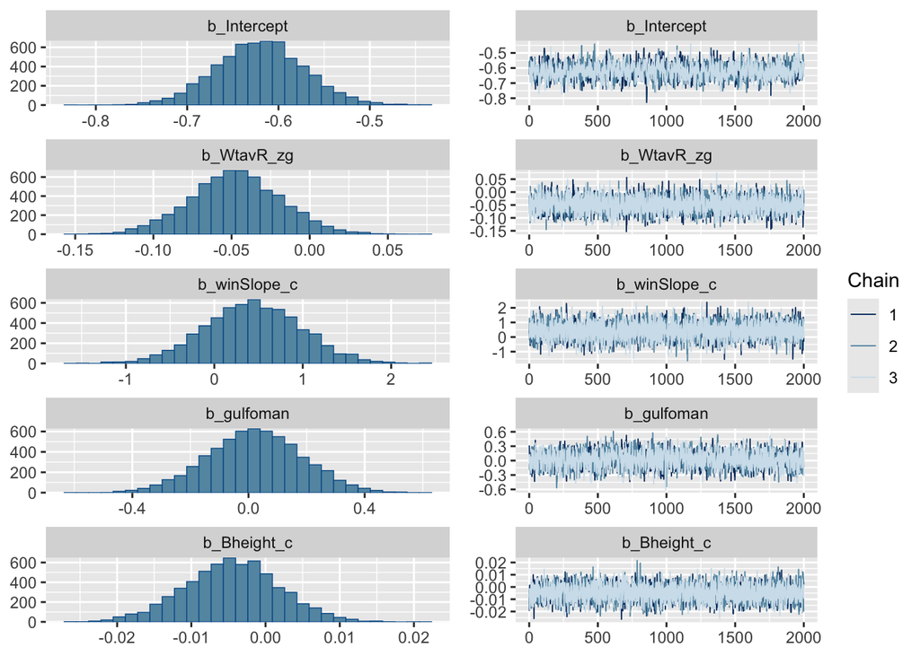

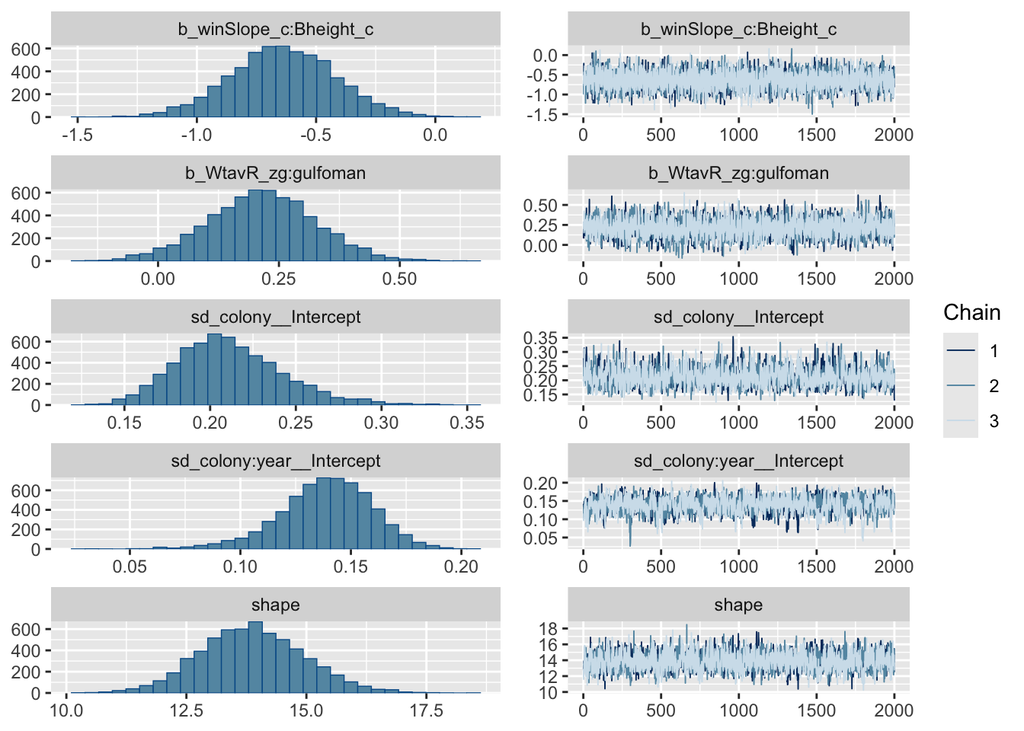

```r
final_main <- readRDS("models/final_main.rds") ## note this is for Rmarkdown purpos
plot(final_main)
```